# Branch Closure Results

# 1 Setup

```r
rm(list = ls())
gc()
```

```
          used (Mb) gc trigger (Mb) max used (Mb)
Ncells  592944 31.7    1347191   72   686445 36.7
Vcells 1098166  8.4    8388608   64  1876002 14.4
```

```r
library(data.table)
library(dplyr)
library(fixest)
library(modelsummary)
library(ggplot2)
library(lubridate)
library(xtable)
library(DescTools)
library(stringr)
library(scales)

# Load summary statistics function
source('https://raw.githubusercontent.com/dratnadiwakara/r-utilities/refs/heads/main/summary_stat_tables.R')

data_dir <- "C:/OneDrive/data/nrs_branch_closure"

# Load deposit beta results from three rate cycles
beta_cycles <- readRDS(file.path(data_dir, "deposit_beta_results.rds"))
```

# 2 Data Preparation

## 2.1 Define Large Banks

Define large banks using CPI-adjusted asset cutoff ($100M in 2024 dollars):

```r
# Load CPI data for inflation adjustment
# Source: FRED CPIAUCSL series
# library(quantmod)
# cpi <- getSymbols("CPIAUCSL",src="FRED",auto.assign = F)
# cpi <- data.table(date=index(cpi),CPI=coredata(cpi))
# cpi <- cpi %>% mutate(year=year(date)) %>%
#        group_by(year) %>%
#       summarize(CPI=last(CPI.CPIAUCSL)) %>% ungroup() %>% data.table()
# saveRDS(cpi,"../data/cpi.rds")

cpi <- readRDS(file.path(data_dir, "cpi.rds"))
cpi[, adj_ratio := CPI / CPI[year == 2024]]
cpi[, asset_cutoff := adj_ratio * 100000000]

# Get all bank-level data across cycles
all_banks <- rbindlist(lapply(names(beta_cycles), function(cycle_name) {
  dt <- copy(beta_cycles[[cycle_name]]$data)
  dt[, cycle := cycle_name]
  # Add year for each cycle (using end year)
  dt[, year := ifelse(cycle == "cycle_0406", 2006,
                     ifelse(cycle == "cycle_1619", 2019, 2023))]
  return(dt)
}))

# Merge with CPI cutoffs
all_banks <- merge(all_banks, cpi[, .(year, asset_cutoff)], by = "year", all.x = TRUE)

# Define large banks
large_banks <- unique(all_banks[bank_assets > asset_cutoff]$ID_RSSD)
```

## 2.2 Prepare Branch Sample

Load branch sample and calculate deposit betas using predictions from bank-level regressions:

```r
# Load branch-level data
branch_sample <- readRDS(file.path(data_dir, "branch_closure_analysis_sample.rds"))

# Add large_bank indicator
branch_sample[, large_bank := ifelse(RSSDID %in% large_banks, 1, 0)]

# Create factor variables needed for prediction
branch_sample[, factor_age_bin := as.factor(age_bin)]

# Predict deposit expense changes for each branch using each cycle's regression
for(i in 1:length(beta_cycles)) {
  cycle_nm <- names(beta_cycles)[i]
  cycle_data <- beta_cycles[[cycle_nm]]$data
  branch_sample[, pred_int_exp_chg := predict(beta_cycles[[i]]$reg, newdata = branch_sample)]
  setnames(branch_sample, "pred_int_exp_chg", paste0("pred_int_exp_chg_", cycle_nm))
}

# Calculate deposit beta based on year and rate changes
# Rate changes: 2004-06: 3.5pp, 2016-19: 2.5pp, 2022-23: 4.0pp
branch_sample[, deposit_beta := ifelse(yr <= 2014, pred_int_exp_chg_cycle_0406 / 3.5,
                                      ifelse(yr <= 2019, pred_int_exp_chg_cycle_1619 / 2.5,
                                             pred_int_exp_chg_cycle_2224 / 4))]

# Calculate deposit franchise value per dollar


# Create rate cycle variable
branch_sample[, rate_cycle := ifelse(yr >= 2004 & yr <= 2006, "1early",
                                    ifelse(yr >= 2016 & yr <= 2019, "2mid",
                                    ifelse(yr >= 2022 & yr <= 2023, "3late", NA)))]


# Create fixed effect variables
branch_sample[, state_yr := paste0(substr(STCNTYBR, 1, 2), "_", yr)]
branch_sample[, county_yr := paste0(STCNTYBR, "_", yr)]
branch_sample[, bank_yr := paste0(RSSDID, "_", yr)]


cat("Branch sample prepared with", nrow(branch_sample), "observations\n")
```

```
Branch sample prepared with 2022023 observations
```

```r
cat("Observations by rate cycle:\n")
```

```
Observations by rate cycle:
```

```r
print(table(branch_sample$rate_cycle, useNA = "ifany"))
```

```
 1early    2mid   3late    <NA>
 236650  347735  154184 1283454
```

## 2.3 Summary Statistics by Bank Size

```r
# Store results in list
result_tables <- list()

# Create table for each cycle
for(i in 1:length(beta_cycles)) {
  cat("\n### Cycle:", names(beta_cycles)[[i]], "\n\n")

  temp <- copy(beta_cycles[[i]]$data)
  temp[, large_bank := ifelse(ID_RSSD %in% large_banks, 1, 0)]
  temp[, family_income := floor(family_income / 1000)]  # Convert to thousands

  # Rename variables for display
  setnames(temp,
           c("deposit_beta", "age", "college_frac", "dividend_frac", "family_income",
             "sophisticated_frac", "bank_hhi", "population_density"),
           new_names <- c("Deposit beta", "Age", "College educated fraction",
                         "Stock market participation frac", "Family income (000)",
                         "Frac. deposits in sophisticated zipcodes", "HHI",
                         "Deposit-weighted Pop. density"))

  cat("Number of banks by size:\n")
  print(table(temp$large_bank))
  cat("\n")

  # Summary stats for large banks
  temp1 <- summary_stats_function(temp[large_bank == 1], new_names)
  temp1 <- temp1 %>% select(-P25, -P50, -P75, -Obs)

  # Summary stats for small banks
  temp2 <- summary_stats_function(temp[large_bank == 0], new_names)
  temp2 <- temp2 %>% select(-P25, -P50, -P75, -Obs)

  # Merge tables
  result_tables[[paste0('bank_stats_', names(beta_cycles)[[i]])]] <-
    merge(temp1, temp2, by = "Variable")

  # Print table (text format)
  md_table((result_tables[[paste0('bank_stats_', names(beta_cycles)[[i]])]]))

  # LaTeX version (uncomment to use)
  # print(xtable(result_tables[[paste0('bank_stats_', names(beta_cycles)[[i]])]]),
  #       table.placement = NULL, floating = FALSE, include.rownames = FALSE,
  #       comment = FALSE, scalebox = 0.8, latex.environments = "center")

  cat("\n\n")
}
```

Table 1: Bank-Level Characteristics by Size and Cycle

### 2.3.1 Cycle: cycle_0406

Number of banks by size:

0 1 5548 27

| Variable | Mean.x | SD.x | P10.x | P90.x | Mean.y | SD.y | P10.y | P90.y |
| --- | --- | --- | --- | --- | --- | --- | --- | --- |
| Age | 37.27 | 2.52 | 34.19 | 38.72 | 39.90 | 4.35 | 34.73 | 45.32 |
| College educated fraction | 0.45 | 0.10 | 0.34 | 0.56 | 0.26 | 0.13 | 0.14 | 0.44 |
| Deposit-weighted Pop. density | 0.46 | 0.14 | 0.31 | 0.60 | 0.13 | 0.20 | 0.01 | 0.51 |
| Deposit beta | 0.29 | 0.10 | 0.14 | 0.40 | 0.23 | 0.11 | 0.10 | 0.38 |
| Family income (000) | 59.52 | 14.01 | 44.80 | 78.40 | 50.26 | 15.56 | 35.00 | 70.00 |
| Frac. deposits in sophisticated zipcodes | 0.62 | 0.25 | 0.35 | 0.86 | 0.43 | 0.41 | 0.00 | 1.00 |
| HHI | 0.25 | 0.17 | 0.15 | 0.36 | 0.22 | 0.12 | 0.10 | 0.37 |
| Stock market participation frac | 0.24 | 0.06 | 0.18 | 0.32 | 0.20 | 0.08 | 0.10 | 0.29 |

### 2.3.2 Cycle: cycle_1619

Number of banks by size:

0 1 4905 34

| Variable | Mean.x | SD.x | P10.x | P90.x | Mean.y | SD.y | P10.y | P90.y |
| --- | --- | --- | --- | --- | --- | --- | --- | --- |
| Age | 36.59 | 4.32 | 30.32 | 41.36 | 40.76 | 4.35 | 35.55 | 45.78 |
| College educated fraction | 0.50 | 0.16 | 0.33 | 0.71 | 0.30 | 0.15 | 0.16 | 0.51 |
| Deposit-weighted Pop. density | 0.52 | 0.16 | 0.34 | 0.68 | 0.16 | 0.23 | 0.01 | 0.60 |
| Deposit beta | 0.24 | 0.09 | 0.15 | 0.37 | 0.17 | 0.12 | 0.03 | 0.34 |
| Family income (000) | 79.94 | 30.36 | 57.80 | 112.40 | 59.03 | 19.32 | 40.00 | 83.00 |
| Frac. deposits in sophisticated zipcodes | 0.66 | 0.33 | 0.00 | 1.00 | 0.46 | 0.41 | 0.00 | 1.00 |
| HHI | 0.25 | 0.15 | 0.14 | 0.35 | 0.23 | 0.13 | 0.11 | 0.38 |
| Stock market participation frac | 0.27 | 0.14 | 0.13 | 0.43 | 0.20 | 0.09 | 0.10 | 0.30 |

### 2.3.3 Cycle: cycle_2224

Number of banks by size:

0 1 4413 27

| Variable | Mean.x | SD.x | P10.x | P90.x | Mean.y | SD.y | P10.y | P90.y |
| --- | --- | --- | --- | --- | --- | --- | --- | --- |
| Age | 36.93 | 4.43 | 30.51 | 41.85 | 40.76 | 4.34 | 35.55 | 45.77 |
| College educated fraction | 0.54 | 0.15 | 0.39 | 0.74 | 0.29 | 0.14 | 0.16 | 0.49 |
| Deposit-weighted Pop. density | 0.54 | 0.15 | 0.36 | 0.70 | 0.15 | 0.22 | 0.01 | 0.58 |
| Deposit beta | 0.31 | 0.13 | 0.19 | 0.50 | 0.19 | 0.12 | 0.04 | 0.36 |
| Family income (000) | 81.19 | 32.79 | 59.60 | 113.40 | 58.29 | 18.69 | 39.00 | 81.00 |
| Frac. deposits in sophisticated zipcodes | 0.73 | 0.27 | 0.43 | 1.00 | 0.45 | 0.41 | 0.00 | 1.00 |
| HHI | 0.24 | 0.10 | 0.13 | 0.33 | 0.23 | 0.13 | 0.11 | 0.39 |
| Stock market participation frac | 0.29 | 0.15 | 0.17 | 0.46 | 0.20 | 0.09 | 0.10 | 0.29 |

# 3 Deposit Beta Regressions

Table showing how depositor characteristics predict deposit beta sensitivity:

```r
# Coefficient dictionary for display names
covariate_labels_dict <- c(
  "college_frac" = "College frac",
  "dividend_frac" = "Stock market frac",
  "log(family_income)" = "Log(Income)",
  "sophisticated_frac" = "Sophisticated frac",
  "factor_age_bin2" = "Age bin 2",
  "factor_age_bin3" = "Age bin 3",
  "factor_age_bin4" = "Age bin 4",
  "bank_hhi" = "Bank HHI",
  "log(bank_assets)" = "Log(Assets)",
  "population_density" = "Pop. density",
  "trans_accts_frac_assets" = "Trans. accounts",
  "uninsured_deposits_frac" = "Uninsured deposits"
)

# Create table using etable
md_table(etable(
  beta_cycles$cycle_0406$reg, beta_cycles$cycle_1619$reg, beta_cycles$cycle_2224$reg,
  beta_cycles$cycle_0406$reg_sophisticated, beta_cycles$cycle_1619$reg_sophisticated, beta_cycles$cycle_2224$reg_sophisticated,
  se.below = TRUE,
  signif.code = c("***" = 0.01, "**" = 0.05, "*" = 0.10),
  headers = list("Early Cycle" = 1, "Mid Cycle" = 1, "Late Cycle" = 1,
                 "Early Cycle" = 1, "Mid Cycle" = 1, "Late Cycle" = 1),
  dict = covariate_labels_dict,
  depvar = FALSE
))
```

```r
# LaTeX version with AER style (uncomment to use)
# etable(
#   beta_cycles$cycle_0406$reg, beta_cycles$cycle_1619$reg, beta_cycles$cycle_2224$reg,
#   beta_cycles$cycle_0406$reg_sophisticated, beta_cycles$cycle_1619$reg_sophisticated, beta_cycles$cycle_2224$reg_sophisticated,
#   se.below = TRUE,
#   signif.code = c("***" = 0.01, "**" = 0.05, "*" = 0.10),
#   headers = list("Early Cycle" = 1, "Mid Cycle" = 1, "Late Cycle" = 1,
#                  "Early Cycle" = 1, "Mid Cycle" = 1, "Late Cycle" = 1),
#   dict = covariate_labels_dict,
#   depvar = FALSE,
#   tex = TRUE,
#   style.tex = style.tex("aer")
# )
```

Table 2: Deposit Beta Regressions

```
|                  |beta_cyc.. |beta_cyc..|beta_cyc..|beta_cyc.. |beta_cyc..|beta_cyc..|
|------------------|-----------|----------|----------|-----------|----------|----------|
|                  |Early Cycle|Mid Cycle |Late Cycle|Early Cycle|Mid Cycle |Late Cycle|
|                  |           |          |          |           |          |          |
|Constant          | 2.035***  | 1.129*** | 1.467*** | 1.350***  | 0.3010   | 0.3708   |
|                  |(0.2935)   |(0.2470)  |(0.4221)  |(0.2601)   |(0.2148)  |(0.3683)  |
|Age bin 2         |-0.0251*   |-0.0036   |-0.0005   |-0.0400*** |-0.0054   |-0.0061   |
|                  |(0.0134)   |(0.0106)  |(0.0182)  |(0.0132)   |(0.0104)  |(0.0179)  |
|Age bin 3         |-0.0664*** |-0.0094   | 0.0009   |-0.0857*** |-0.0088   |-0.0041   |
|                  |(0.0154)   |(0.0122)  |(0.0212)  |(0.0145)   |(0.0117)  |(0.0201)  |
|Age bin 4         |-0.0465**  |-0.0683***|-0.0841***|-0.0651*** |-0.0597***|-0.0807***|
|                  |(0.0190)   |(0.0170)  |(0.0295)  |(0.0179)   |(0.0162)  |(0.0281)  |
|Log(Income)       |-0.1543*** |-0.0891***|-0.1415***|-0.0866*** |-0.0080   |-0.0333   |
|                  |(0.0275)   |(0.0231)  |(0.0394)  |(0.0238)   |(0.0197)  |(0.0337)  |
|Stock market frac |-0.1500    | 0.1919** | 0.1521   |           |          |          |
|                  |(0.1002)   |(0.0794)  |(0.1423)  |           |          |          |
|College frac      | 0.7138*** | 0.3518***| 0.6255***|           |          |          |
|                  |(0.0737)   |(0.0590)  |(0.1040)  |           |          |          |
|Bank HHI          |-0.0951**  |-0.0508   |-0.1893***|-0.0889**  |-0.0462   |-0.1861***|
|                  |(0.0419)   |(0.0338)  |(0.0576)  |(0.0421)   |(0.0340)  |(0.0579)  |
|Log(Assets)       | 0.0252*** | 0.0195***| 0.0444***| 0.0298*** | 0.0220***| 0.0480***|
|                  |(0.0046)   |(0.0032)  |(0.0056)  |(0.0046)   |(0.0032)  |(0.0056)  |
|Pop. density      | 0.1015*** | 0.0645** | 0.2394***| 0.2579*** | 0.1446***| 0.3794***|
|                  |(0.0344)   |(0.0259)  |(0.0449)  |(0.0306)   |(0.0229)  |(0.0396)  |
|Trans. accounts   |-0.3288*** |-0.4559***|-0.4938***|-0.3480*** |-0.4662***|-0.5140***|
|                  |(0.0658)   |(0.0468)  |(0.0804)  |(0.0662)   |(0.0469)  |(0.0806)  |
|Uninsured deposits| 0.1669*** |-0.1125***| 0.3718***| 0.2144*** |-0.0828***| 0.4218***|
|                  |(0.0415)   |(0.0294)  |(0.0510)  |(0.0415)   |(0.0294)  |(0.0509)  |
|Sophisticated frac|           |          |          | 0.0861*** | 0.0639***| 0.1048***|
|                  |           |          |          |(0.0144)   |(0.0122)  |(0.0209)  |
|__________________|__________ |__________|__________|__________ |__________|__________|
|S.E. type         |IID        |IID       |IID       |IID        |IID       |IID       |
|Observations      |5,575      |4,939     |4,440     |5,575      |4,939     |4,440     |
|R2                |0.11567    |0.11480   |0.19410   |0.10419    |0.10569   |0.18718   |
|Adj. R2           |0.11392    |0.11283   |0.19210   |0.10258    |0.10387   |0.18535   |
```

# 4 Distribution of Deposit Betas

## 4.1 Bank-Level

Distribution of deposit betas across cycles, comparing large and small banks:

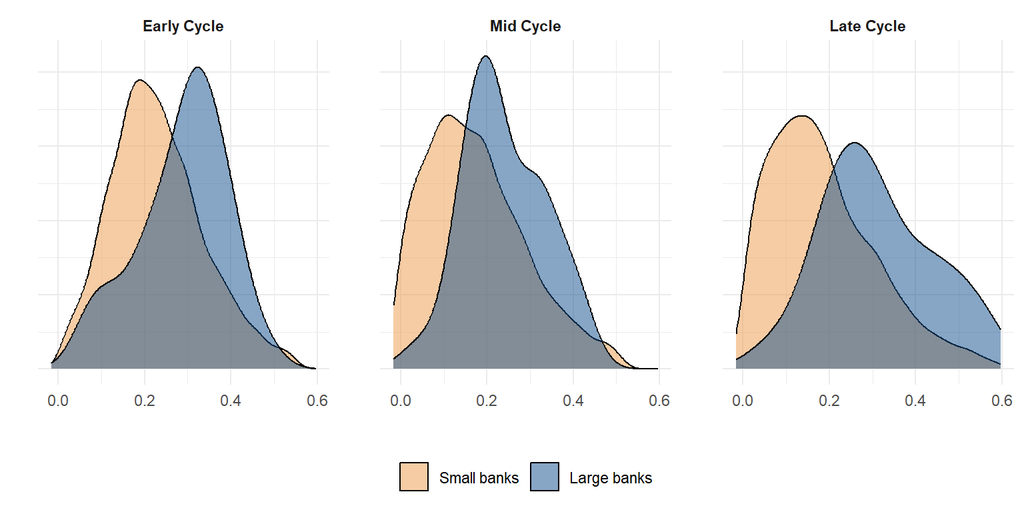

Figure 1: Bank-Level Deposit Beta Distribution

```r
# Combine data from all cycles
beta_density <- data.table()
for(i in 1:length(beta_cycles)) {
  cycle_nm <- names(beta_cycles)[[i]]
  temp <- beta_cycles[[i]]$data[, .(ID_RSSD, deposit_beta)]
  temp[, large_bank := ifelse(ID_RSSD %in% large_banks, 1, 0)]
  temp[, cycle := cycle_nm]
  beta_density <- rbind(beta_density, temp)
}

# Create density plot
g <- ggplot(beta_density, aes(x = deposit_beta, fill = factor(large_bank))) +
  geom_density(alpha = 0.5) +
  facet_wrap(~cycle, labeller = as_labeller(c(
    "cycle_0406" = "Early Cycle",
    "cycle_1619" = "Mid Cycle",
    "cycle_2224" = "Late Cycle"
  ))) +
  scale_x_continuous(n.breaks = 4) +
  scale_fill_manual(
    values = c("1" = "dodgerblue4", "0" = "tan2"),
    labels = c("1" = "Large banks", "0" = "Small banks")
  ) +
  labs(x = "", y = "") +
  theme_minimal() +
  theme(
    legend.title = element_blank(),
    legend.position = "bottom",
    axis.text.y = element_blank(),
    panel.spacing = unit(2, "lines"),
    strip.text = element_text(face = "bold")
  )

print(g)

# Uncomment to save
# ggsave(file.path(data_dir, "../figures/beta_density_bank.jpg"), g,
#        width = 5, height = 3)
```

## 4.2 Branch-Level

Distribution of deposit betas at the branch level:

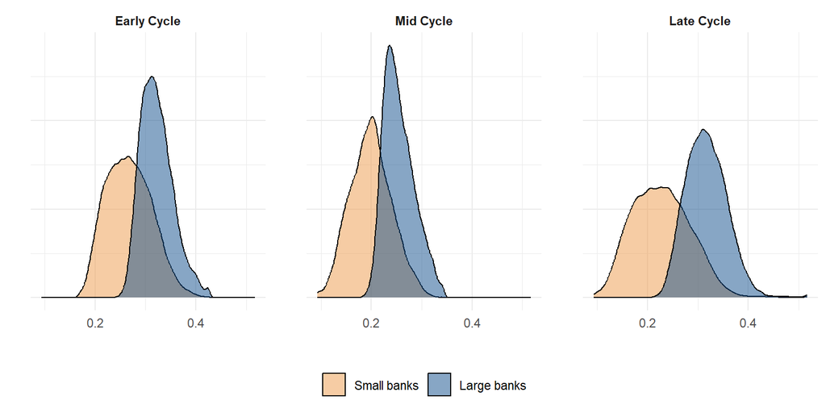

Figure 2: Branch-Level Deposit Beta Distribution

```r
# Calculate branch-level average deposit beta by cycle
beta_density_branch <- branch_sample[!is.na(rate_cycle),
                                     .(deposit_beta = mean(deposit_beta, na.rm = TRUE)),
                                     by = .(rate_cycle, large_bank, UNINUMBR)]

# Winsorize at 0.1% and 99.9% by cycle
beta_density_branch[, `:=`(
  q1 = quantile(deposit_beta, probs = 0.001, na.rm = TRUE),
  q2 = quantile(deposit_beta, probs = 0.999, na.rm = TRUE)
), by = rate_cycle]

beta_density_branch[, deposit_beta := ifelse(deposit_beta < q1, q1,
                                             ifelse(deposit_beta > q2, q2, deposit_beta))]

# Create density plot
g <- ggplot(beta_density_branch, aes(x = deposit_beta, fill = factor(large_bank))) +
  geom_density(alpha = 0.5) +
  facet_wrap(~rate_cycle, labeller = as_labeller(c(
    "1early" = "Early Cycle",
    "2mid" = "Mid Cycle",
    "3late" = "Late Cycle"
  ))) +
  scale_x_continuous(n.breaks = 4) +
  scale_fill_manual(
    values = c("1" = "dodgerblue4", "0" = "tan2"),
    labels = c("1" = "Large banks", "0" = "Small banks")
  ) +
  labs(x = "", y = "") +
  theme_minimal() +
  theme(
    legend.title = element_blank(),
    legend.position = "bottom",
    axis.text.y = element_blank(),
    panel.spacing = unit(2, "lines"),
    strip.text = element_text(face = "bold")
  )

print(g)

# Uncomment to save
# ggsave(file.path(data_dir, "../figures/beta_density_branch.jpg"), g,
#        width = 5, height = 3)
```

# 5 Beta Correlations Across Cycles

## 5.1 Branch-Level Correlations

### 5.1.1 Mid Cycle vs Late Cycle

Scatter plot showing correlation of deposit betas between mid cycle (2016-2019) and late cycle (2022-2024) at the branch level:

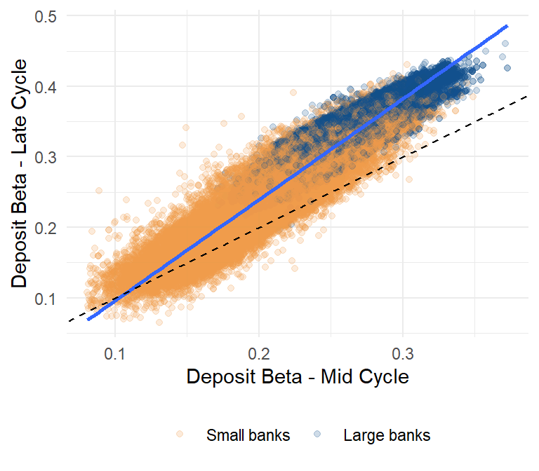

Figure 3: Branch-Level Deposit Beta: Mid Cycle vs Late Cycle

```r
# Prepare data: get deposit betas for 2019-2020
temp <- branch_sample[yr %in% 2019:2020, c("UNINUMBR", "yr", "deposit_beta", "large_bank")]
temp <- dcast(temp, UNINUMBR + large_bank ~ yr, value.var = "deposit_beta", fun.aggregate = mean)
names(temp) <- c("UNINUMBR", "large_bank", "cycle1619", "cycle2224")

# Create scatter plot
g <- ggplot(temp[cycle1619 > 0.08 & cycle1619 < 0.4], aes(x = cycle1619, y = cycle2224)) +
  geom_point(aes(color = factor(large_bank)), alpha = 0.2) +
  geom_smooth(method = "lm") +
  geom_abline(intercept = 0, slope = 1, linetype = "dashed") +
  scale_color_manual(
    values = c("1" = "dodgerblue4", "0" = "tan2"),
    labels = c("1" = "Large banks", "0" = "Small banks")
  ) +
  labs(x = "Deposit Beta - Mid Cycle", y = "Deposit Beta - Late Cycle") +
  theme_minimal() +
  theme(legend.position = "bottom", legend.title = element_blank())

print(g)

# Uncomment to save
# ggsave(file.path(data_dir, "../figures/df_scatter_branch_mid_late.jpg"), g,
#        width = 4, height = 3.5)
```

### 5.1.2 Early Cycle vs Mid Cycle

Scatter plot showing correlation of deposit betas between early cycle (2004-2006) and mid cycle (2016-2019) at the branch level:

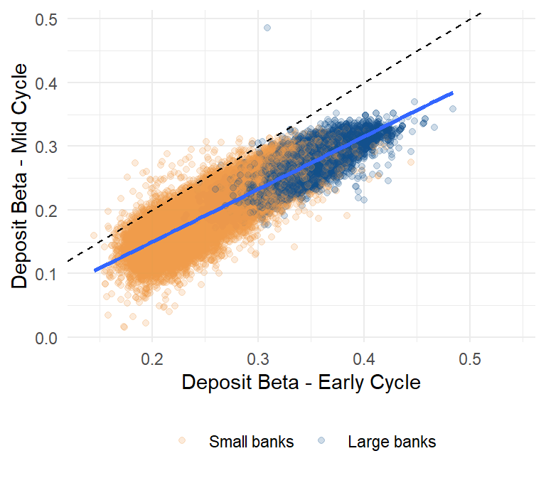

Figure 4: Branch-Level Deposit Beta: Early Cycle vs Mid Cycle

```r
# Prepare data: get deposit betas for 2006 and 2019
temp <- branch_sample[yr %in% c(2006, 2019) & is.finite(deposit_beta),
                      c("UNINUMBR", "yr", "deposit_beta", "large_bank")]
temp <- dcast(temp, UNINUMBR + large_bank ~ yr, value.var = "deposit_beta", fun.aggregate = mean)
names(temp) <- c("UNINUMBR", "large_bank", "cycle0406", "cycle1619")

# Create scatter plot
g <- ggplot(temp, aes(x = cycle0406, y = cycle1619)) +
  geom_point(aes(color = factor(large_bank)), alpha = 0.2) +
  geom_smooth(method = "lm") +
  geom_abline(intercept = 0, slope = 1, linetype = "dashed") +
  scale_color_manual(
    values = c("1" = "dodgerblue4", "0" = "tan2"),
    labels = c("1" = "Large banks", "0" = "Small banks")
  ) +
  labs(x = "Deposit Beta - Early Cycle", y = "Deposit Beta - Mid Cycle") +
  theme_minimal() +
  theme(legend.position = "bottom", legend.title = element_blank())

print(g)

# Uncomment to save
# ggsave(file.path(data_dir, "../figures/df_scatter_branch_early_mid.jpg"), g,
#        width = 4, height = 3.5)
```

## 5.2 Bank-Level Correlations

### 5.2.1 Early Cycle vs Mid Cycle

Scatter plot showing correlation of deposit betas between early and mid cycles at the bank level:

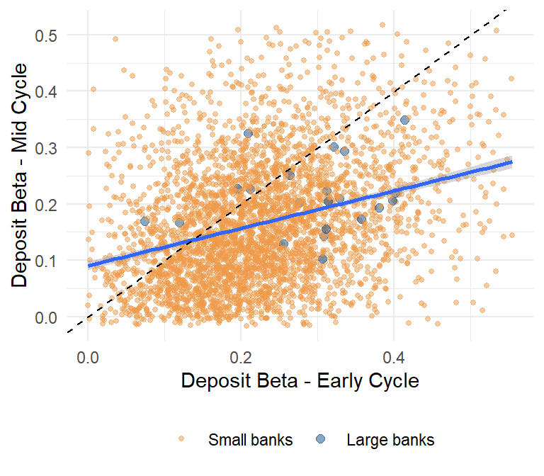

Figure 5: Bank-Level Deposit Beta: Early Cycle vs Mid Cycle

```r
# Prepare bank-level data across all cycles
beta_density_bank <- data.table()
for(i in 1:length(beta_cycles)) {
  cycle_nm <- names(beta_cycles)[[i]]
  cycle <- beta_cycles[[i]]
  temp <- cycle$data[, .(ID_RSSD, deposit_beta)]
  temp[, large_bank := ifelse(ID_RSSD %in% large_banks, 1, 0)]
  temp[, cycle := cycle_nm]
  beta_density_bank <- rbind(beta_density_bank, temp)
}

# Reshape to wide format
beta_density_bank <- dcast(beta_density_bank, ID_RSSD + large_bank ~ cycle,
                           value.var = "deposit_beta", fun.aggregate = mean)
beta_density_bank <- beta_density_bank[complete.cases(beta_density_bank)]
setnames(beta_density_bank, c("cycle_0406", "cycle_1619", "cycle_2224"),
         c("early", "mid", "late"))

# Create scatter plot: early vs mid
g1 <- ggplot(beta_density_bank, aes(x = early, y = mid)) +
  geom_point(aes(color = factor(large_bank), size = factor(large_bank)), alpha = 0.5) +
  geom_smooth(method = "lm") +
  geom_abline(intercept = 0, slope = 1, linetype = "dashed") +
  scale_size_manual(
    values = c("1" = 2, "0" = 1),
    labels = c("1" = "Large banks", "0" = "Small banks")
  ) +
  scale_color_manual(
    values = c("1" = "dodgerblue4", "0" = "tan2"),
    labels = c("1" = "Large banks", "0" = "Small banks")
  ) +
  labs(x = "Deposit Beta - Early Cycle", y = "Deposit Beta - Mid Cycle") +
  theme_minimal() +
  theme(legend.position = "bottom", legend.title = element_blank())

print(g1)

# Uncomment to save
# ggsave(file.path(data_dir, "../figures/df_scatter_bank_early_mid.jpg"), g1,
#        width = 4, height = 3.5)
```

### 5.2.2 Mid Cycle vs Late Cycle

Scatter plot showing correlation of deposit betas between mid and late cycles at the bank level:

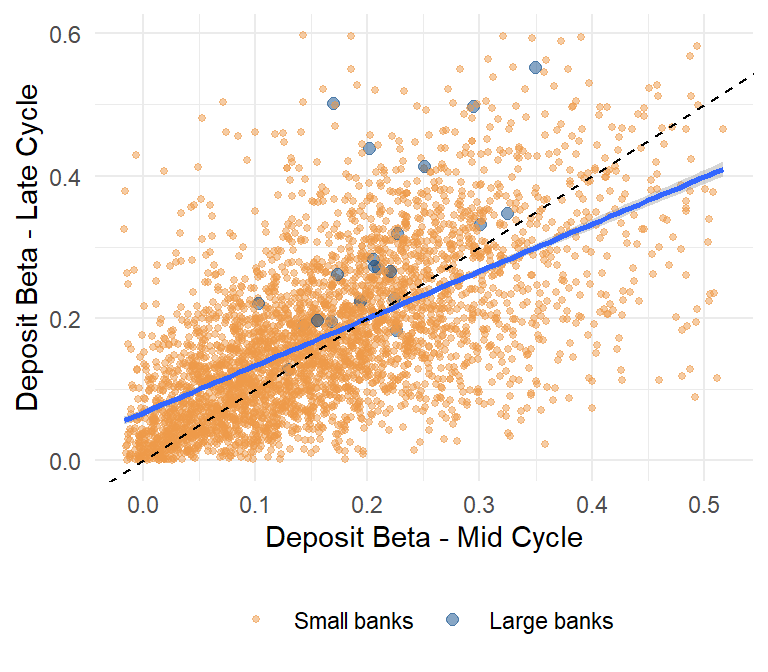

Figure 6: Bank-Level Deposit Beta: Mid Cycle vs Late Cycle

```r
# Create scatter plot: mid vs late
g2 <- ggplot(beta_density_bank, aes(x = mid, y = late)) +
  geom_point(aes(color = factor(large_bank), size = factor(large_bank)), alpha = 0.5) +
  geom_smooth(method = "lm") +
  geom_abline(intercept = 0, slope = 1, linetype = "dashed") +
  scale_size_manual(
    values = c("1" = 2, "0" = 1),
    labels = c("1" = "Large banks", "0" = "Small banks")
  ) +
  scale_color_manual(
    values = c("1" = "dodgerblue4", "0" = "tan2"),
    labels = c("1" = "Large banks", "0" = "Small banks")
  ) +
  labs(x = "Deposit Beta - Mid Cycle", y = "Deposit Beta - Late Cycle") +
  theme_minimal() +
  theme(legend.position = "bottom", legend.title = element_blank())

print(g2)

# Uncomment to save
# ggsave(file.path(data_dir, "../figures/df_scatter_bank_mid_late.jpg"), g2,
#        width = 4, height = 3.5)
```

# 6 Deposit Beta and Closure Rates (Univariate)

Examining the relationship between deposit beta deciles and branch closure rates across different time periods:

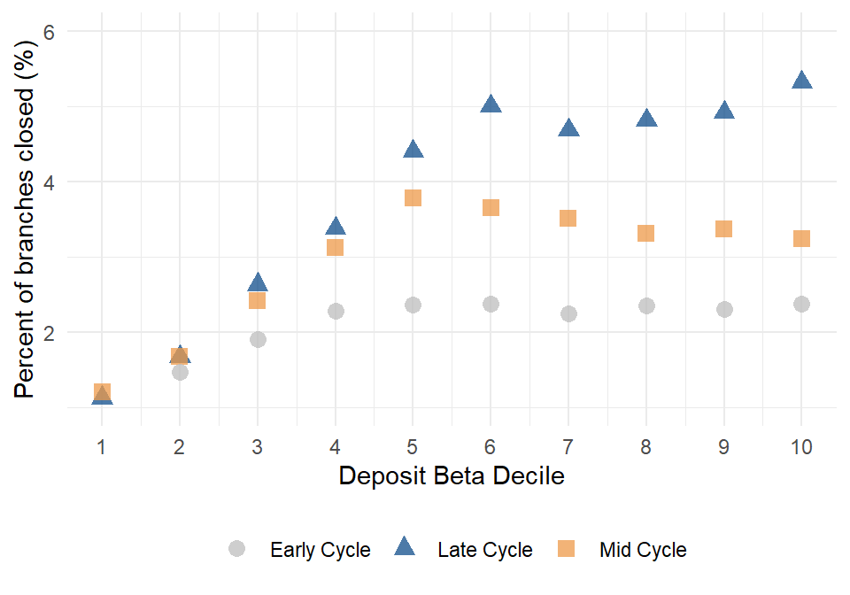

Figure 7: Branch Closure Rates by Deposit Beta Decile Across Cycles

```r
# Prepare data with cycles and beta deciles
temp <- copy(branch_sample)
temp[, cycle := ifelse(yr >= 2020, 1, ifelse(yr >= 2014, 2, 3))]
temp[, beta_q := ntile(deposit_beta, 10), by = .(yr)]

# Calculate closure rates by beta decile for each cycle
temp1 <- temp[yr %in% 2020:2023, .(frac_branches_closed = mean(closed)), by = beta_q]
temp1[, cycle := "Late Cycle"]

temp2 <- temp[yr %in% 2015:2019, .(frac_branches_closed = mean(closed, na.rm = TRUE)), by = beta_q]
temp2[, cycle := "Mid Cycle"]

temp3 <- temp[yr %in% 2001:2014, .(frac_branches_closed = mean(closed, na.rm = TRUE)), by = beta_q]
temp3[, cycle := "Early Cycle"]

# Combine and winsorize
temp <- rbind(temp1, temp2, temp3)
temp[, frac_branches_closed := Winsorize(frac_branches_closed,
                                         quantile(frac_branches_closed, probs = c(0.05, 0.95), na.rm = TRUE)),
     by = .(beta_q, cycle)]

# Create plot
g <- ggplot(temp, aes(x = beta_q, y = frac_branches_closed * 100, color = cycle)) +
  geom_point(size = 3, alpha = 0.75, aes(shape = cycle)) +
  scale_x_continuous(n.breaks = 10) +
  scale_color_manual(
    values = c("Late Cycle" = "dodgerblue4",
               "Mid Cycle" = "tan2",
               "Early Cycle" = "gray")
  ) +
  ylim(c(1, 6)) +
  theme_minimal() +
  labs(x = "Deposit Beta Decile", y = "Percent of branches closed (%)") +
  theme(legend.position = "bottom", legend.title = element_blank())

print(g)

# Uncomment to save
# ggsave(file.path(data_dir, "../figures/univar_branch.jpg"), g,
#        width = 5, height = 3.5)
```

# 7 Descriptive Statistics: Branch Closure Sample

Summary statistics for the branch closure analysis sample, comparing large and small banks across different time periods:

## 7.1 Panel A: Large Banks

```r
# Prepare data
temp <- copy(branch_sample[is.finite(deposit_beta) & DEPSUMBR > 0 & is.finite(DEPSUMBR)])
temp[, lag_branch_deposit_amount := floor(lag_branch_deposit_amount / 1000)]
temp[, log_deposits := log(DEPSUMBR)]
# Remove any remaining -Inf values
temp <- temp[is.finite(log_deposits)]

# Rename variables
setnames(temp,
         c("closed", "deposit_beta", "lag_branch_deposit_amount", "log_deposits",
           "lag_county_deposit_gr", "lag_hmda_mtg_amt_gr", "lag_cra_loan_amount_amt_lt_1m_gr",
           "lag_establishment_gr", "lag_payroll_gr", "same_zip_prior_3yr_branches",
           "legacy_branch", "population_density", "lmi"),
         new_names <- c("Closed", "Deposit Beta", "Deposits (mn)", "log(Deposits)",
                        "Deposit 3yr growth", "Mortgage 3yr growth", "CRA 3yr growth",
                        "Establishments 3yr growth", "Payroll 3yr growth",
                        "Acq. branch/presence", "Branch owned 3plus years",
                        "Population density (1k km)", "Low to Moderate Income Area"))

# Calculate within-FE standard deviations for mid cycle (2019)
temp_df_mid <- copy(branch_sample[is.finite(deposit_beta) & DEPSUMBR > 0 & is.finite(DEPSUMBR) & yr == 2019 & large_bank == 1])
temp_df_mid[, log_deposits := log(DEPSUMBR)]
temp_df_mid <- temp_df_mid[is.finite(log_deposits)]

reg_beta <- feols(deposit_beta ~ 0 | county_yr + bank_yr, temp_df_mid)
temp_df_mid[, pred_deposit_beta := predict(reg_beta, newdata = temp_df_mid)]
temp_df_mid[, resid_deposit_beta := deposit_beta - pred_deposit_beta]
sd_within_beta_mid <- sd(temp_df_mid$resid_deposit_beta, na.rm = TRUE)

reg_log <- feols(log_deposits ~ 0 | county_yr + bank_yr, temp_df_mid)
temp_df_mid[, pred_log_deposits := predict(reg_log, newdata = temp_df_mid)]
temp_df_mid[, resid_log_deposits := log_deposits - pred_log_deposits]
sd_within_log_mid <- sd(temp_df_mid$resid_log_deposits, na.rm = TRUE)

# Calculate within-FE standard deviations for early cycle (2012)
temp_df_early <- copy(branch_sample[is.finite(deposit_beta) & DEPSUMBR > 0 & is.finite(DEPSUMBR) & yr == 2012 & large_bank == 1])
temp_df_early[, log_deposits := log(DEPSUMBR)]
temp_df_early <- temp_df_early[is.finite(log_deposits)]

reg_beta <- feols(deposit_beta ~ 0 | county_yr + bank_yr, temp_df_early)
temp_df_early[, pred_deposit_beta := predict(reg_beta, newdata = temp_df_early)]
temp_df_early[, resid_deposit_beta := deposit_beta - pred_deposit_beta]
sd_within_beta_early <- sd(temp_df_early$resid_deposit_beta, na.rm = TRUE)

reg_log <- feols(log_deposits ~ 0 | county_yr + bank_yr, temp_df_early)
temp_df_early[, pred_log_deposits := predict(reg_log, newdata = temp_df_early)]
temp_df_early[, resid_log_deposits := log_deposits - pred_log_deposits]
sd_within_log_early <- sd(temp_df_early$resid_log_deposits, na.rm = TRUE)

# Mid cycle stats (2019)
temp1 <- summary_stats_function(temp[large_bank == 1 & yr == 2019], new_names)
temp1 <- temp1 %>% select(-P25, -P50, -P75, -Obs) %>% data.table()
temp1[, `SD (within)` := NA_real_]
temp1[Variable == "Deposit Beta", `SD (within)` := sd_within_beta_mid]
temp1[Variable == "log(Deposits)", `SD (within)` := sd_within_log_mid]
temp1 <- temp1[, .(Variable, Mean, SD, `SD (within)`, P10, P90)]

# Early cycle stats (2012)
temp2 <- summary_stats_function(temp[large_bank == 1 & yr == 2012], new_names)
temp2 <- temp2 %>% select(-P25, -P50, -P75, -Obs) %>% data.table()
temp2[, `SD (within)` := NA_real_]
temp2[Variable == "Deposit Beta", `SD (within)` := sd_within_beta_early]
temp2[Variable == "log(Deposits)", `SD (within)` := sd_within_log_early]
temp2 <- temp2[, .(Variable, Mean, SD, `SD (within)`, P10, P90)]

# Merge tables
result_large <- merge(temp1, temp2, by = "Variable", suffixes = c(".mid", ".early"))

# Reorder variables
variable_order <- c('Closed', 'Deposit Beta', 'log(Deposits)',
                   'Acq. branch/presence', 'Branch owned 3plus years',
                   'Deposit 3yr growth', 'CRA 3yr growth',
                   'Establishments 3yr growth', 'Low to Moderate Income Area',
                   'Mortgage 3yr growth', 'Payroll 3yr growth',
                   'Population density (1k km)')

result_large <- result_large[order(factor(Variable, levels = variable_order))]

# Get observation counts
obs_mid <- nrow(temp[large_bank == 1 & yr == 2019])
obs_early <- nrow(temp[large_bank == 1 & yr == 2012])

# Print table
cat("\\begin{table}[htbp]\n")
```

```r
# Also print as kable for viewing
md_table(result_large)
```

Table 3: Descriptive Statistics - Large Banks

| Variable | Mean.mid | SD.mid | SD (within).mid | P10.mid | P90.mid | Mean.early | SD.early | SD (within).early | P10.early | P90.early |
| --- | --- | --- | --- | --- | --- | --- | --- | --- | --- | --- |
| Closed | 0.04 | 0.19 | NA | 0.00 | 0.00 | 0.02 | 0.15 | NA | 0.00 | 0.00 |
| Deposit Beta | 0.25 | 0.03 | 0.0203876 | 0.22 | 0.30 | 0.33 | 0.03 | 0.01873649 | 0.29 | 0.37 |
| log(Deposits) | 11.22 | 1.04 | 0.9065994 | 10.10 | 12.32 | 10.67 | 1.10 | 0.99119014 | 9.46 | 11.82 |
| Acq. branch/presence | 0.00 | 0.07 | NA | 0.00 | 0.00 | 0.02 | 0.12 | NA | 0.00 | 0.00 |
| Branch owned 3plus years | 0.98 | 0.15 | NA | 1.00 | 1.00 | 0.82 | 0.39 | NA | 0.00 | 1.00 |
| Deposit 3yr growth | 0.05 | 0.03 | NA | 0.01 | 0.09 | 0.09 | 0.08 | NA | 0.00 | 0.20 |
| CRA 3yr growth | 0.04 | 0.06 | NA | -0.02 | 0.11 | -0.11 | 0.05 | NA | -0.16 | -0.06 |
| Establishments 3yr growth | 0.01 | 0.01 | NA | 0.00 | 0.03 | -0.01 | 0.01 | NA | -0.02 | 0.00 |
| Low to Moderate Income Area | 0.31 | 0.15 | NA | 0.10 | 0.50 | 0.30 | 0.15 | NA | 0.10 | 0.48 |
| Mortgage 3yr growth | 0.04 | 0.07 | NA | -0.04 | 0.12 | 0.01 | 0.09 | NA | -0.09 | 0.15 |
| Payroll 3yr growth | 0.04 | 0.02 | NA | 0.02 | 0.07 | 0.00 | 0.02 | NA | -0.02 | 0.02 |
| Population density (1k km) | 0.41 | 0.28 | NA | 0.04 | 0.75 | 0.37 | 0.26 | NA | 0.04 | 0.69 |
| Deposits (mn) | 209.76 | 3270.37 | NA | 23.00 | 216.00 | 118.94 | 1817.36 | NA | 12.00 | 134.00 |

## 7.2 Panel B: Small Banks

```r
# Calculate within-FE standard deviations for mid cycle (2019)
temp_df_mid <- copy(branch_sample[is.finite(deposit_beta) & DEPSUMBR > 0 & is.finite(DEPSUMBR) & yr == 2019 & large_bank == 0])
temp_df_mid[, log_deposits := log1p(DEPSUMBR)]
temp_df_mid <- temp_df_mid[is.finite(log_deposits)]

reg_beta <- feols(deposit_beta ~ 0 | county_yr + bank_yr, temp_df_mid)
temp_df_mid[, pred_deposit_beta := predict(reg_beta, newdata = temp_df_mid)]
temp_df_mid[, resid_deposit_beta := deposit_beta - pred_deposit_beta]
sd_within_beta_mid <- sd(temp_df_mid$resid_deposit_beta, na.rm = TRUE)

reg_log <- feols(log_deposits ~ 0 | county_yr + bank_yr, temp_df_mid)
temp_df_mid[, pred_log_deposits := predict(reg_log, newdata = temp_df_mid)]
temp_df_mid[, resid_log_deposits := log_deposits - pred_log_deposits]
sd_within_log_mid <- sd(temp_df_mid$resid_log_deposits, na.rm = TRUE)

# Calculate within-FE standard deviations for early cycle (2012)
temp_df_early <- copy(branch_sample[is.finite(deposit_beta) & DEPSUMBR > 0 & is.finite(DEPSUMBR) & yr == 2012 & large_bank == 0])
temp_df_early[, log_deposits := log(DEPSUMBR)]
temp_df_early <- temp_df_early[is.finite(log_deposits)]

reg_beta <- feols(deposit_beta ~ 0 | county_yr + bank_yr, temp_df_early)
temp_df_early[, pred_deposit_beta := predict(reg_beta, newdata = temp_df_early)]
temp_df_early[, resid_deposit_beta := deposit_beta - pred_deposit_beta]
sd_within_beta_early <- sd(temp_df_early$resid_deposit_beta, na.rm = TRUE)

reg_log <- feols(log_deposits ~ 0 | county_yr + bank_yr, temp_df_early)
temp_df_early[, pred_log_deposits := predict(reg_log, newdata = temp_df_early)]
temp_df_early[, resid_log_deposits := log_deposits - pred_log_deposits]
sd_within_log_early <- sd(temp_df_early$resid_log_deposits, na.rm = TRUE)

# Mid cycle stats (2019)
temp1 <- summary_stats_function(temp[large_bank == 0 & yr == 2019 & DEPSUMBR>0], new_names)
temp1 <- temp1 %>% select(-P25, -P50, -P75, -Obs) %>% data.table()
temp1[, `SD (within)` := NA_real_]
temp1[Variable == "Deposit Beta", `SD (within)` := sd_within_beta_mid]
temp1[Variable == "log(Deposits)", `SD (within)` := sd_within_log_mid]
temp1 <- temp1[, .(Variable, Mean, SD, `SD (within)`, P10, P90)]

# Early cycle stats (2012)
temp2 <- summary_stats_function(temp[large_bank == 0 & yr == 2012 & DEPSUMBR>0], new_names)
temp2 <- temp2 %>% select(-P25, -P50, -P75, -Obs) %>% data.table()
temp2[, `SD (within)` := NA_real_]
temp2[Variable == "Deposit Beta", `SD (within)` := sd_within_beta_early]
temp2[Variable == "log(Deposits)", `SD (within)` := sd_within_log_early]
temp2 <- temp2[, .(Variable, Mean, SD, `SD (within)`, P10, P90)]

# Merge tables
result_small <- merge(temp1, temp2, by = "Variable", suffixes = c(".mid", ".early"))

# Reorder variables
result_small <- result_small[order(factor(Variable, levels = variable_order))]

# Get observation counts
obs_mid <- nrow(temp[large_bank == 0 & yr == 2019 & DEPSUMBR>0])
obs_early <- nrow(temp[large_bank == 0 & yr == 2012 & DEPSUMBR>0])

# Print table
cat("\\begin{table}[htbp]\n")
```

```r
# Also print as kable for viewing
md_table(result_small)
```

Table 4: Descriptive Statistics - Small Banks

| Variable | Mean.mid | SD.mid | SD (within).mid | P10.mid | P90.mid | Mean.early | SD.early | SD (within).early | P10.early | P90.early |
| --- | --- | --- | --- | --- | --- | --- | --- | --- | --- | --- |
| Closed | 0.02 | 0.14 | NA | 0.00 | 0.00 | 0.02 | 0.15 | NA | 0.00 | 0.00 |
| Deposit Beta | 0.20 | 0.04 | 0.01514574 | 0.14 | 0.25 | 0.26 | 0.04 | 0.01483463 | 0.20 | 0.31 |
| log(Deposits) | 10.54 | 1.25 | 0.93699738 | 9.15 | 11.86 | 10.21 | 1.28 | 0.94903153 | 8.81 | 11.56 |
| Acq. branch/presence | 0.01 | 0.10 | NA | 0.00 | 0.00 | 0.01 | 0.08 | NA | 0.00 | 0.00 |
| Branch owned 3plus years | 0.91 | 0.29 | NA | 1.00 | 1.00 | 0.90 | 0.30 | NA | 1.00 | 1.00 |
| Deposit 3yr growth | 0.04 | 0.03 | NA | 0.00 | 0.08 | 0.08 | 0.07 | NA | 0.00 | 0.18 |
| CRA 3yr growth | 0.05 | 0.12 | NA | -0.04 | 0.16 | -0.10 | 0.07 | NA | -0.17 | -0.03 |
| Establishments 3yr growth | 0.01 | 0.01 | NA | -0.01 | 0.03 | -0.01 | 0.01 | NA | -0.02 | 0.00 |
| Low to Moderate Income Area | 0.26 | 0.18 | NA | 0.00 | 0.48 | 0.26 | 0.17 | NA | 0.00 | 0.47 |
| Mortgage 3yr growth | 0.04 | 0.07 | NA | -0.04 | 0.12 | 0.00 | 0.08 | NA | -0.09 | 0.10 |
| Payroll 3yr growth | 0.04 | 0.03 | NA | 0.00 | 0.07 | 0.00 | 0.03 | NA | -0.02 | 0.03 |
| Population density (1k km) | 0.22 | 0.26 | NA | 0.01 | 0.75 | 0.22 | 0.25 | NA | 0.01 | 0.69 |
| Deposits (mn) | 84.09 | 719.79 | NA | 9.00 | 136.00 | 56.19 | 341.95 | NA | 6.00 | 102.40 |

# 8 Branch Closure Analysis

## 8.1 Define Control Variables

Set up control variable specifications for closure regressions:

```r
# State-level controls with extensive covariates
setFixest_fml(
  ..ctrl_state_closure = ~ log(lag_branch_deposit_amount) + same_zip_prior_3yr_branches +
                           legacy_branch + lag_county_deposit_gr +
                           lag_hmda_mtg_amt_gr + lag_cra_loan_amount_amt_lt_1m_gr +
                           lag_establishment_gr + lag_payroll_gr + lmi +
                           log(lag_bank_county_mortgage_volume) + log(lag_bank_county_cra_volume)| state_yr + bank_yr,

  # County-level controls with simplified specification
  ..ctrl_county_closure = ~ log(lag_branch_deposit_amount) + same_zip_prior_3yr_branches +
                            legacy_branch + log(lag_bank_county_mortgage_volume) + log(lag_bank_county_cra_volume)| county_yr + bank_yr
)
```

## 8.2 Baseline Closure Model

Relationship between deposit beta and branch closure probability:

```r
# Run regressions for all banks, large banks, and small banks
closure_regs <- list(
  # All banks
  feols(closed ~ deposit_beta + ..ctrl_state_closure,
        data = branch_sample, vcov = ~RSSDID),
  feols(closed ~ deposit_beta + ..ctrl_county_closure,
        data = branch_sample, vcov = ~RSSDID),

  # Large banks
  feols(closed ~ deposit_beta + ..ctrl_state_closure,
        data = branch_sample[large_bank == 1], vcov = ~RSSDID),
  feols(closed ~ deposit_beta + ..ctrl_county_closure,
        data = branch_sample[large_bank == 1], vcov = ~RSSDID),

  # Small banks
  feols(closed ~ deposit_beta + ..ctrl_state_closure,
        data = branch_sample[large_bank == 0], vcov = ~RSSDID),
  feols(closed ~ deposit_beta + ..ctrl_county_closure,
        data = branch_sample[large_bank == 0], vcov = ~RSSDID)
)

# Display results
md_table(etable(
  closure_regs,
  se.below = TRUE,
  signif.code = c("***" = 0.01, "**" = 0.05, "*" = 0.10),
  headers = list("All Banks" = 2, "Large Banks" = 2, "Small Banks" = 2),
  dict = c("deposit_beta" = "Deposit beta"),
  depvar = FALSE
))
```

```r
# LaTeX version (uncomment to use)
# etable(
#   closure_regs,
#   se.below = TRUE,
#   signif.code = c("***" = 0.01, "**" = 0.05, "*" = 0.10),
#   headers = list("All Banks" = 2, "Large Banks" = 2, "Small Banks" = 2),
#   dict = c("deposit_beta" = "Deposit beta"),
#   depvar = FALSE,
#   tex = TRUE,
#   style.tex = style.tex("aer")
# )
```

Table 5: Baseline Branch Closure Regressions

```
|                                    |model 1   |model 2   |model 3    |model 4    |model 5    |model 6    |
|------------------------------------|----------|----------|-----------|-----------|-----------|-----------|
|                                    |All Banks |All Banks |Large Banks|Large Banks|Small Banks|Small Banks|
|                                    |          |          |           |           |           |           |
|Deposit beta                        | 0.0818***| 0.0982***| 0.0984*** | 0.1487*** | 0.0751*** | 0.0663*** |
|                                    |(0.0097)  |(0.0114)  |(0.0184)   |(0.0206)   |(0.0086)   |(0.0097)   |
|log(lag_branch_deposit_amount)      |-0.0158***|-0.0157***|-0.0184*** |-0.0183*** |-0.0142*** |-0.0141*** |
|                                    |(0.0005)  |(0.0005)  |(0.0010)   |(0.0010)   |(0.0005)   |(0.0005)   |
|same_zip_prior_3yr_branches         | 0.0480***| 0.0461***| 0.0456*** | 0.0406*** | 0.0491*** | 0.0472*** |
|                                    |(0.0061)  |(0.0062)  |(0.0100)   |(0.0108)   |(0.0070)   |(0.0069)   |
|legacy_branch                       |-0.0068***|-0.0068***|-0.0055*** |-0.0071*** |-0.0082*** |-0.0082*** |
|                                    |(0.0013)  |(0.0013)  |(0.0020)   |(0.0024)   |(0.0013)   |(0.0013)   |
|lag_county_deposit_gr               | 0.0006   |          | 0.0021    |           | 0.0001    |           |
|                                    |(0.0006)  |          |(0.0014)   |           |(0.0006)   |           |
|lag_hmda_mtg_amt_gr                 |-0.0072***|          |-0.0047    |           |-0.0073*** |           |
|                                    |(0.0025)  |          |(0.0053)   |           |(0.0021)   |           |
|lag_cra_loan_amount_amt_lt_1m_gr    |-0.0005   |          |-0.0003    |           |-0.0002    |           |
|                                    |(0.0005)  |          |(0.0019)   |           |(0.0005)   |           |
|lag_establishment_gr                |-0.1329***|          |-0.2682*** |           |-0.0448**  |           |
|                                    |(0.0240)  |          |(0.0444)   |           |(0.0176)   |           |
|lag_payroll_gr                      |-0.0026   |          |-0.0102    |           | 0.0030    |           |
|                                    |(0.0052)  |          |(0.0101)   |           |(0.0058)   |           |
|lmi                                 |-0.0044***|          |-0.0119*** |           | 0.0006    |           |
|                                    |(0.0014)  |          |(0.0023)   |           |(0.0011)   |           |
|log(lag_bank_county_mortgage_volume)|-0.0004   |-0.0006** |-0.0010    | 0.0003    |-0.0002    |-0.0007*** |
|                                    |(0.0003)  |(0.0003)  |(0.0007)   |(0.0011)   |(0.0002)   |(0.0002)   |
|log(lag_bank_county_cra_volume)     |-0.0004   |-0.0007** | 0.0004    | 0.0011    |-0.0004*   |-0.0008*** |
|                                    |(0.0003)  |(0.0004)  |(0.0006)   |(0.0008)   |(0.0003)   |(0.0003)   |
|Fixed-Effects:                      |----------|----------|---------- |---------- |---------- |---------- |
|state_yr                            |Yes       |No        |Yes        |No         |Yes        |No         |
|bank_yr                             |Yes       |Yes       |Yes        |Yes        |Yes        |Yes        |
|county_yr                           |No        |Yes       |No         |Yes        |No         |Yes        |
|____________________________________|__________|__________|__________ |__________ |__________ |__________ |
|S.E.: Clustered                     |by: RSSDID|by: RSSDID|by: RSSDID |by: RSSDID |by: RSSDID |by: RSSDID |
|Observations                        |1,844,166 |1,844,186 |710,740    |710,749    |1,133,426  |1,133,437  |
|R2                                  |0.09690   |0.12827   |0.04775    |0.11197    |0.14823    |0.19947    |
|Within R2                           |0.01369   |0.01335   |0.01345    |0.01264    |0.01443    |0.01406    |
```

## 8.3 Closures by Time Period

Analyze closure patterns across different economic regimes:

```r
# Define year ranges for different economic periods
yr_range <- list(
  "2001-2007" = 2000:2007,  # Pre-crisis
  "2008-2011" = 2008:2011,  # Financial crisis
  "2012-2019" = 2012:2019,  # Post-crisis recovery
  "2020-2023" = 2020:2024   # Pandemic era
)

# Large banks - closures by regime
closure_large_by_regime <- list(
  feols(closed ~ deposit_beta + ..ctrl_state_closure,
        data = branch_sample[large_bank == 1 & yr %in% yr_range[[1]]], vcov = ~RSSDID),
  feols(closed ~ deposit_beta + ..ctrl_county_closure,
        data = branch_sample[large_bank == 1 & yr %in% yr_range[[1]]], vcov = ~RSSDID),
  feols(closed ~ deposit_beta + ..ctrl_state_closure,
        data = branch_sample[large_bank == 1 & yr %in% yr_range[[2]]], vcov = ~RSSDID),
  feols(closed ~ deposit_beta + ..ctrl_county_closure,
        data = branch_sample[large_bank == 1 & yr %in% yr_range[[2]]], vcov = ~RSSDID),
  feols(closed ~ deposit_beta + ..ctrl_state_closure,
        data = branch_sample[large_bank == 1 & yr %in% yr_range[[3]]], vcov = ~RSSDID),
  feols(closed ~ deposit_beta + ..ctrl_county_closure,
        data = branch_sample[large_bank == 1 & yr %in% yr_range[[3]]], vcov = ~RSSDID),
  feols(closed ~ deposit_beta + ..ctrl_state_closure,
        data = branch_sample[large_bank == 1 & yr %in% yr_range[[4]]], vcov = ~RSSDID),
  feols(closed ~ deposit_beta + ..ctrl_county_closure,
        data = branch_sample[large_bank == 1 & yr %in% yr_range[[4]]], vcov = ~RSSDID)
)

# Display mean closure rates for large banks
cat("Large banks - Mean closure rates by period:\n")
```

```r
for(i in 1:length(yr_range)) {
  mean_close <- mean(branch_sample[large_bank == 1 & yr %in% yr_range[[i]]]$closed, na.rm = TRUE)
  cat(names(yr_range)[i], ":", round(mean_close * 100, 3), "%\n")
}
```

```r
cat("\n")
```

```r
# Display results
md_table(etable(
  closure_large_by_regime,
  se.below = TRUE,
  signif.code = c("***" = 0.01, "**" = 0.05, "*" = 0.10),
  headers = list("2001-07" = 2, "2008-11" = 2, "2012-19" = 2, "2020-23" = 2),
  dict = c("deposit_beta" = "Deposit beta"),
  depvar = FALSE
))
```

```r
cat("\n\n")
```

```r
# Small banks - closures by regime
closure_small_by_regime <- list(
  feols(closed ~ deposit_beta + ..ctrl_state_closure,
        data = branch_sample[large_bank == 0 & yr %in% yr_range[[1]]], vcov = ~RSSDID),
  feols(closed ~ deposit_beta + ..ctrl_county_closure,
        data = branch_sample[large_bank == 0 & yr %in% yr_range[[1]]], vcov = ~RSSDID),
  feols(closed ~ deposit_beta + ..ctrl_state_closure,
        data = branch_sample[large_bank == 0 & yr %in% yr_range[[2]]], vcov = ~RSSDID),
  feols(closed ~ deposit_beta + ..ctrl_county_closure,
        data = branch_sample[large_bank == 0 & yr %in% yr_range[[2]]], vcov = ~RSSDID),
  feols(closed ~ deposit_beta + ..ctrl_state_closure,
        data = branch_sample[large_bank == 0 & yr %in% yr_range[[3]]], vcov = ~RSSDID),
  feols(closed ~ deposit_beta + ..ctrl_county_closure,
        data = branch_sample[large_bank == 0 & yr %in% yr_range[[3]]], vcov = ~RSSDID),
  feols(closed ~ deposit_beta + ..ctrl_state_closure,
        data = branch_sample[large_bank == 0 & yr %in% yr_range[[4]]], vcov = ~RSSDID),
  feols(closed ~ deposit_beta + ..ctrl_county_closure,
        data = branch_sample[large_bank == 0 & yr %in% yr_range[[4]]], vcov = ~RSSDID)
)

# Display mean closure rates for small banks
cat("Small banks - Mean closure rates by period:\n")
```

```r
for(i in 1:length(yr_range)) {
  mean_close <- mean(branch_sample[large_bank == 0 & yr %in% yr_range[[i]]]$closed, na.rm = TRUE)
  cat(names(yr_range)[i], ":", round(mean_close * 100, 3), "%\n")
}
```

```r
cat("\n")
```

```r
# Display results
md_table(etable(
  closure_small_by_regime,
  se.below = TRUE,
  signif.code = c("***" = 0.01, "**" = 0.05, "*" = 0.10),
  headers = list("2001-07" = 2, "2008-11" = 2, "2012-19" = 2, "2020-23" = 2),
  dict = c("deposit_beta" = "Deposit beta"),
  depvar = FALSE
))
```

```r
# LaTeX versions (uncomment to use)
# etable(
#   closure_large_by_regime,
#   se.below = TRUE,
#   signif.code = c("***" = 0.01, "**" = 0.05, "*" = 0.10),
#   headers = list("2001-07" = 2, "2008-11" = 2, "2012-19" = 2, "2020-23" = 2),
#   dict = c("deposit_beta" = "Deposit beta"),
#   depvar = FALSE,
#   tex = TRUE,
#   style.tex = style.tex("aer")
# )
#
# etable(
#   closure_small_by_regime,
#   se.below = TRUE,
#   signif.code = c("***" = 0.01, "**" = 0.05, "*" = 0.10),
#   headers = list("2001-07" = 2, "2008-11" = 2, "2012-19" = 2, "2020-23" = 2),
#   dict = c("deposit_beta" = "Deposit beta"),
#   depvar = FALSE,
#   tex = TRUE,
#   style.tex = style.tex("aer")
# )
```

Table 6

```
Large banks - Mean closure rates by period:
```

```
2001-2007 : 2.255 %
2008-2011 : 2.179 %
2012-2019 : 3.277 %
2020-2023 : 5.038 %
```

```
|                                    |model 1   |model 2   |model 3   |model 4   |model 5   |model 6   |model 7   |model 8   |
|------------------------------------|----------|----------|----------|----------|----------|----------|----------|----------|
|                                    |2001-07   |2001-07   |2008-11   |2008-11   |2012-19   |2012-19   |2020-23   |2020-23   |
|                                    |          |          |          |          |          |          |          |          |
|Deposit beta                        | 0.0813***| 0.0970***| 0.0842***| 0.0792***| 0.0907** | 0.1395***| 0.1461***| 0.2659***|
|                                    |(0.0144)  |(0.0233)  |(0.0218)  |(0.0220)  |(0.0353)  |(0.0382)  |(0.0251)  |(0.0338)  |
|log(lag_branch_deposit_amount)      |-0.0154***|-0.0154***|-0.0136***|-0.0134***|-0.0203***|-0.0201***|-0.0234***|-0.0238***|
|                                    |(0.0021)  |(0.0022)  |(0.0025)  |(0.0026)  |(0.0017)  |(0.0018)  |(0.0044)  |(0.0041)  |
|same_zip_prior_3yr_branches         | 0.0302*  | 0.0264   | 0.0423** | 0.0398** | 0.0179** | 0.0166** | 0.0903***| 0.0793***|
|                                    |(0.0170)  |(0.0205)  |(0.0164)  |(0.0171)  |(0.0080)  |(0.0079)  |(0.0223)  |(0.0235)  |
|legacy_branch                       |-0.0012   |-0.0003   |-0.0101** |-0.0095** |-0.0162** |-0.0176** | 0.0142***| 0.0063   |
|                                    |(0.0022)  |(0.0028)  |(0.0037)  |(0.0038)  |(0.0070)  |(0.0069)  |(0.0050)  |(0.0065)  |
|lag_county_deposit_gr               | 0.0037** |          | 0.0127   |          |-0.0036   |          |-0.0407** |          |
|                                    |(0.0015)  |          |(0.0123)  |          |(0.0125)  |          |(0.0164)  |          |
|lag_hmda_mtg_amt_gr                 |-0.0049   |          | 0.0054   |          |-0.0097   |          | 0.0004   |          |
|                                    |(0.0045)  |          |(0.0117)  |          |(0.0094)  |          |(0.0091)  |          |
|lag_cra_loan_amount_amt_lt_1m_gr    | 0.0006   |          |-0.0079   |          | 2.89e-5  |          | 0.0018   |          |
|                                    |(0.0017)  |          |(0.0088)  |          |(0.0088)  |          |(0.0123)  |          |
|lag_establishment_gr                |-0.0538   |          |-0.1097** |          |-0.3289***|          |-0.5655***|          |
|                                    |(0.0673)  |          |(0.0504)  |          |(0.1043)  |          |(0.1126)  |          |
|lag_payroll_gr                      |-0.0045   |          |-0.0567***|          |-0.0216   |          | 0.0277   |          |
|                                    |(0.0117)  |          |(0.0137)  |          |(0.0229)  |          |(0.0229)  |          |
|lmi                                 |-0.0039   |          |-0.0084** |          |-0.0095** |          |-0.0230***|          |
|                                    |(0.0036)  |          |(0.0034)  |          |(0.0040)  |          |(0.0064)  |          |
|log(lag_bank_county_mortgage_volume)| 0.0013*  | 0.0014   |-0.0003   |-0.0006   |-0.0025*  |-0.0011   |-0.0009   | 0.0008   |
|                                    |(0.0007)  |(0.0016)  |(0.0006)  |(0.0017)  |(0.0015)  |(0.0024)  |(0.0019)  |(0.0020)  |
|log(lag_bank_county_cra_volume)     | 0.0002   |-0.0005   | 0.0003   | 0.0001   | 0.0002   | 0.0009   | 0.0023   | 0.0080** |
|                                    |(0.0008)  |(0.0011)  |(0.0004)  |(0.0006)  |(0.0016)  |(0.0021)  |(0.0021)  |(0.0031)  |
|Fixed-Effects:                      |----------|----------|----------|----------|----------|----------|----------|----------|
|state_yr                            |Yes       |No        |Yes       |No        |Yes       |No        |Yes       |No        |
|bank_yr                             |Yes       |Yes       |Yes       |Yes       |Yes       |Yes       |Yes       |Yes       |
|county_yr                           |No        |Yes       |No        |Yes       |No        |Yes       |No        |Yes       |
|____________________________________|__________|__________|__________|__________|__________|__________|__________|__________|
|S.E.: Clustered                     |by: RSSDID|by: RSSDID|by: RSSDID|by: RSSDID|by: RSSDID|by: RSSDID|by: RSSDID|by: RSSDID|
|Observations                        |133,751   |133,751   |132,643   |132,643   |293,054   |293,054   |151,292   |151,301   |
|R2                                  |0.05768   |0.12974   |0.03346   |0.08618   |0.04031   |0.10593   |0.04991   |0.11352   |
|Within R2                           |0.01676   |0.01614   |0.01423   |0.01320   |0.01542   |0.01361   |0.01303   |0.01266   |
```

```
Small banks - Mean closure rates by period:
```

```
2001-2007 : 2.077 %
2008-2011 : 2.087 %
2012-2019 : 2.459 %
2020-2023 : 2.444 %
```

```
|                                    |model 1   |model 2   |model 3   |model 4   |model 5   |model 6   |model 7   |model 8      |
|------------------------------------|----------|----------|----------|----------|----------|----------|----------|-------------|
|                                    |2001-07   |2001-07   |2008-11   |2008-11   |2012-19   |2012-19   |2020-23   |2020-23      |
|                                    |          |          |          |          |          |          |          |             |
|Deposit beta                        | 0.0585***| 0.0798***| 0.1151***| 0.0829***| 0.0731***| 0.0678***| 0.0698***|    0.0472***|
|                                    |(0.0128)  |(0.0173)  |(0.0201)  |(0.0245)  |(0.0182)  |(0.0199)  |(0.0131)  |   (0.0157)  |
|log(lag_branch_deposit_amount)      |-0.0108***|-0.0107***|-0.0148***|-0.0148***|-0.0164***|-0.0162***|-0.0163***|   -0.0162***|
|                                    |(0.0011)  |(0.0011)  |(0.0007)  |(0.0007)  |(0.0007)  |(0.0006)  |(0.0008)  |   (0.0008)  |
|same_zip_prior_3yr_branches         | 0.0462***| 0.0449***| 0.0563***| 0.0527***| 0.0548***| 0.0529***| 0.0445***|    0.0419***|
|                                    |(0.0149)  |(0.0144)  |(0.0096)  |(0.0097)  |(0.0089)  |(0.0089)  |(0.0107)  |   (0.0110)  |
|legacy_branch                       |-0.0044***|-0.0045** |-0.0084***|-0.0090***|-0.0093***|-0.0088***|-0.0120***|   -0.0123***|
|                                    |(0.0017)  |(0.0022)  |(0.0029)  |(0.0029)  |(0.0020)  |(0.0020)  |(0.0034)  |   (0.0037)  |
|lag_county_deposit_gr               |-0.0001   |          | 0.0116   |          | 0.0104   |          |-0.0139   |             |
|                                    |(0.0006)  |          |(0.0116)  |          |(0.0088)  |          |(0.0090)  |             |
|lag_hmda_mtg_amt_gr                 |-0.0063** |          |-0.0180** |          |-0.0069   |          |-0.0065   |             |
|                                    |(0.0025)  |          |(0.0086)  |          |(0.0061)  |          |(0.0047)  |             |
|lag_cra_loan_amount_amt_lt_1m_gr    | 0.0004   |          |-0.0068   |          | 0.0001   |          |-0.0060*  |             |
|                                    |(0.0005)  |          |(0.0049)  |          |(0.0027)  |          |(0.0031)  |             |
|lag_establishment_gr                |-0.0467*  |          |-0.0507*  |          |-0.0435   |          |-0.0191   |             |
|                                    |(0.0275)  |          |(0.0281)  |          |(0.0319)  |          |(0.0397)  |             |
|lag_payroll_gr                      | 0.0002   |          | 0.0153   |          | 0.0029   |          |-0.0014   |             |
|                                    |(0.0089)  |          |(0.0135)  |          |(0.0103)  |          |(0.0147)  |             |
|lmi                                 | 0.0018   |          | 0.0030   |          |-0.0005   |          |-0.0025   |             |
|                                    |(0.0017)  |          |(0.0027)  |          |(0.0021)  |          |(0.0024)  |             |
|log(lag_bank_county_mortgage_volume)| 0.0006   | 0.0002   | 0.0007   | 0.0003   |-0.0008** |-0.0012***|-0.0007   |   -0.0014***|
|                                    |(0.0004)  |(0.0004)  |(0.0005)  |(0.0005)  |(0.0004)  |(0.0004)  |(0.0004)  |   (0.0005)  |
|log(lag_bank_county_cra_volume)     |-0.0008   |-0.0013** |-0.0010** |-0.0015***|-0.0005   |-0.0006   | 0.0005   |-9e-5        |
|                                    |(0.0006)  |(0.0006)  |(0.0004)  |(0.0005)  |(0.0005)  |(0.0004)  |(0.0005)  |   (0.0005)  |
|Fixed-Effects:                      |----------|----------|----------|----------|----------|----------|----------|-------------|
|state_yr                            |Yes       |No        |Yes       |No        |Yes       |No        |Yes       |No           |
|bank_yr                             |Yes       |Yes       |Yes       |Yes       |Yes       |Yes       |Yes       |Yes          |
|county_yr                           |No        |Yes       |No        |Yes       |No        |Yes       |No        |Yes          |
|____________________________________|__________|__________|__________|__________|__________|__________|__________|_____________|
|S.E.: Clustered                     |by: RSSDID|by: RSSDID|by: RSSDID|by: RSSDID|by: RSSDID|by: RSSDID|by: RSSDID|by: RSSDID   |
|Observations                        |345,173   |345,174   |188,738   |188,738   |380,675   |380,675   |218,840   |218,850      |
|R2                                  |0.13557   |0.18882   |0.17157   |0.21703   |0.15056   |0.20319   |0.13729   |0.18837      |
|Within R2                           |0.01421   |0.01378   |0.01666   |0.01607   |0.01512   |0.01468   |0.01405   |0.01380      |
```

# 9 Branch Visit Patterns

## 9.1 Closures and Branch Usage (Pandemic Era)

Examine how changes in branch usage during the pandemic relate to closure decisions:

```r
# Load branch visit data (SafeGraph)
branch_visits <- readRDS(file.path(data_dir, "bank_branch_visits_count_2019_2022.rds"))
branch_visits[, yr := year(DATE_RANGE_START)]
branch_visits <- branch_visits[yr %in% c(2019, 2021)]

# Load branch characteristics to get zip codes
branch_chars <- readRDS('C:/OneDrive/data/fdic_sod_1995_2025_simple.rds')
branch_chars <- data.table(branch_chars)
if("YEAR" %in% names(branch_chars)) setnames(branch_chars, "YEAR", "yr")
if("ZIPBR" %in% names(branch_chars)) setnames(branch_chars, "ZIPBR", "zip")

# Get unique UNINUMBR-zip combinations (use most recent year for each branch)
branch_zip <- branch_chars[order(UNINUMBR, -yr)][, .SD[1], by = UNINUMBR][, .(UNINUMBR, zip)]

# Merge branch visits with zip codes
branch_visits <- merge(branch_visits, branch_zip, by = "UNINUMBR")

# Calculate average distance from home in 2019 (pre-pandemic baseline)
distance <- branch_visits[yr == 2019, .(distance_km = mean(DISTANCE_FROM_HOME, na.rm = TRUE) / 1000),
                         by = zip]

# Aggregate visits to zip level for zips with 5+ branches
branch_visits <- branch_visits[, .(no_branches = .N, number_of_visits = sum(RAW_VISIT_COUNTS, na.rm = TRUE)),
                               by = .(zip, yr)]
branch_visits <- branch_visits[no_branches > 4]

# Calculate change in visits between 2019 and 2021
branch_visits <- dcast(branch_visits, zip ~ yr, value.var = "number_of_visits")
branch_visits[, change_visits := (`2019` - `2021`) / `2019`]

# Merge with distance and winsorize
branch_visits <- merge(branch_visits, distance, by = "zip")
branch_visits[, change_visits := Winsorize(change_visits,
                                           quantile(change_visits, probs = c(0.01, 0.99), na.rm = TRUE))]
branch_visits[, distance_km := Winsorize(distance_km,
                                         quantile(distance_km, probs = c(0.01, 0.99), na.rm = TRUE))]
branch_visits[, zip := str_pad(zip, 5, "left", "0")]

cat("Branch usage data prepared for", nrow(branch_visits), "zip codes\n")
```

```
Branch usage data prepared for 14499 zip codes
```

```r
# Merge branch sample with usage data for 2020-2023 period
closures <- merge(branch_sample[yr >= 2020],
                 branch_visits[, c("zip", "change_visits", "distance_km")],
                 by = "zip")

# Update fixed effects for this subsample
closures[, bank_year := paste(RSSDID, yr)]
closures[, state_year := paste(substr(STCNTYBR, 1, 2), yr)]

# Display mean closure rates
cat("Mean closure rates (2020-2023):\n")
```

```r
cat("All banks:", round(mean(closures$closed, na.rm = TRUE) * 100, 3), "%\n")
```

```r
cat("Large banks:", round(mean(closures[large_bank == 1]$closed, na.rm = TRUE) * 100, 3), "%\n")
```

```r
cat("Small banks:", round(mean(closures[large_bank == 0]$closed, na.rm = TRUE) * 100, 3), "%\n\n")
```

```r
# Regressions with usage variables
closure_usage_full <- list(
  feols(closed ~ deposit_beta + ..ctrl_state_closure,
        data = closures, vcov = ~RSSDID),
  feols(closed ~ deposit_beta + ..ctrl_county_closure,
        data = closures, vcov = ~RSSDID),
  feols(closed ~ deposit_beta + change_visits + log(distance_km) + ..ctrl_state_closure,
        data = closures, vcov = ~RSSDID),
  feols(closed ~ deposit_beta + change_visits + log(distance_km) + ..ctrl_county_closure,
        data = closures, vcov = ~RSSDID)
)

cat("Full sample results:\n")
```

```r
md_table(etable(
  closure_usage_full,
  se.below = TRUE,
  signif.code = c("***" = 0.01, "**" = 0.05, "*" = 0.10),
  headers = list("Baseline" = 2, "With Usage" = 2),
  dict = c("deposit_beta" = "Deposit beta", "change_visits" = "Drop in visits",
           "log(distance_km)" = "Log(Distance)"),
  depvar = FALSE
))
```

```r
cat("\n\n")
```

```r
# By bank size
closure_usage_by_size <- list(
  # Large banks
  feols(closed ~ deposit_beta + ..ctrl_state_closure,
        data = closures[large_bank == 1], vcov = ~RSSDID),
  feols(closed ~ deposit_beta + ..ctrl_county_closure,
        data = closures[large_bank == 1], vcov = ~RSSDID),
  feols(closed ~ deposit_beta + change_visits + log(distance_km) + ..ctrl_state_closure,
        data = closures[large_bank == 1], vcov = ~RSSDID),
  feols(closed ~ deposit_beta + change_visits + log(distance_km) + ..ctrl_county_closure,
        data = closures[large_bank == 1], vcov = ~RSSDID),
  # Small banks
  feols(closed ~ deposit_beta + ..ctrl_state_closure,
        data = closures[large_bank == 0], vcov = ~RSSDID),
  feols(closed ~ deposit_beta + ..ctrl_county_closure,
        data = closures[large_bank == 0], vcov = ~RSSDID),
  feols(closed ~ deposit_beta + change_visits + log(distance_km) + ..ctrl_state_closure,
        data = closures[large_bank == 0], vcov = ~RSSDID),
  feols(closed ~ deposit_beta + change_visits + log(distance_km) + ..ctrl_county_closure,
        data = closures[large_bank == 0], vcov = ~RSSDID)
)

cat("Results by bank size:\n")
```

```r
md_table(etable(
  closure_usage_by_size,
  se.below = TRUE,
  signif.code = c("***" = 0.01, "**" = 0.05, "*" = 0.10),
  headers = list("Large Banks" = 4, "Small Banks" = 4),
  dict = c("deposit_beta" = "Deposit beta", "change_visits" = "Drop in visits",
           "log(distance_km)" = "Log(Distance)"),
  depvar = FALSE
))
```

```r
# LaTeX versions (uncomment to use)
# etable(
#   closure_usage_full,
#   se.below = TRUE,
#   signif.code = c("***" = 0.01, "**" = 0.05, "*" = 0.10),
#   headers = list("Baseline" = 2, "With Usage" = 2),
#   dict = c("deposit_beta" = "Deposit beta", "change_visits" = "Drop in visits",
#            "log(distance_km)" = "Log(Distance)"),
#   depvar = FALSE,
#   tex = TRUE,
#   style.tex = style.tex("aer")
# )
```

Table 7

```
Mean closure rates (2020-2023):
```

```
All banks: 3.436 %
```

```
Large banks: 4.854 %
```

```
Small banks: 2.399 %
```

```
Full sample results:
```

```
|                                    |model 1   |model 2   |model 3   |model 4   |
|------------------------------------|----------|----------|----------|----------|
|                                    |Baseline  |Baseline  |With Usage|With Usage|
|                                    |          |          |          |          |
|Deposit beta                        | 0.1287***| 0.1597***| 0.1018***| 0.1214***|
|                                    |(0.0138)  |(0.0203)  |(0.0119)  |(0.0164)  |
|log(lag_branch_deposit_amount)      |-0.0184***|-0.0185***|-0.0186***|-0.0187***|
|                                    |(0.0018)  |(0.0018)  |(0.0018)  |(0.0018)  |
|same_zip_prior_3yr_branches         | 0.0692***| 0.0676***| 0.0685***| 0.0668***|
|                                    |(0.0146)  |(0.0149)  |(0.0147)  |(0.0149)  |
|legacy_branch                       |-0.0021   |-0.0023   |-0.0025   |-0.0027   |
|                                    |(0.0042)  |(0.0042)  |(0.0042)  |(0.0042)  |
|lag_county_deposit_gr               |-0.0218** |          |-0.0245** |          |
|                                    |(0.0098)  |          |(0.0099)  |          |
|lag_hmda_mtg_amt_gr                 |-0.0008   |          |-0.0014   |          |
|                                    |(0.0057)  |          |(0.0056)  |          |
|lag_cra_loan_amount_amt_lt_1m_gr    |-0.0040   |          |-0.0034   |          |
|                                    |(0.0040)  |          |(0.0039)  |          |
|lag_establishment_gr                |-0.2245***|          |-0.2295***|          |
|                                    |(0.0730)  |          |(0.0708)  |          |
|lag_payroll_gr                      | 0.0144   |          | 0.0100   |          |
|                                    |(0.0149)  |          |(0.0148)  |          |
|lmi                                 |-0.0105***|          |-0.0095***|          |
|                                    |(0.0035)  |          |(0.0033)  |          |
|log(lag_bank_county_mortgage_volume)|-0.0008   |-0.0015** |-0.0008   |-0.0013** |
|                                    |(0.0006)  |(0.0007)  |(0.0006)  |(0.0007)  |
|log(lag_bank_county_cra_volume)     | 0.0014*  | 0.0015   | 0.0016** | 0.0016*  |
|                                    |(0.0007)  |(0.0009)  |(0.0008)  |(0.0010)  |
|Drop in visits                      |          |          | 0.0054***| 0.0044** |
|                                    |          |          |(0.0015)  |(0.0018)  |
|Log(Distance)                       |          |          | 0.0055***| 0.0080***|
|                                    |          |          |(0.0010)  |(0.0012)  |
|Fixed-Effects:                      |----------|----------|----------|----------|
|state_yr                            |Yes       |No        |Yes       |No        |
|bank_yr                             |Yes       |Yes       |Yes       |Yes       |
|county_yr                           |No        |Yes       |No        |Yes       |
|____________________________________|__________|__________|__________|__________|
|S.E.: Clustered                     |by: RSSDID|by: RSSDID|by: RSSDID|by: RSSDID|
|Observations                        |347,931   |347,937   |347,383   |347,389   |
|R2                                  |0.08373   |0.11207   |0.08394   |0.11240   |
|Within R2                           |0.01228   |0.01206   |0.01254   |0.01237   |
```

```
Results by bank size:
```

```
|                                    |model 1    |model 2    |model 3    |model 4    |model 5    |model 6    |model 7    |model 8    |
|------------------------------------|-----------|-----------|-----------|-----------|-----------|-----------|-----------|-----------|
|                                    |Large Banks|Large Banks|Large Banks|Large Banks|Small Banks|Small Banks|Small Banks|Small Banks|
|                                    |           |           |           |           |           |           |           |           |
|Deposit beta                        | 0.1645*** | 0.2794*** | 0.1226*** | 0.2014*** | 0.0938*** | 0.0759*** | 0.0745*** | 0.0598*** |
|                                    |(0.0256)   |(0.0357)   |(0.0215)   |(0.0305)   |(0.0141)   |(0.0174)   |(0.0132)   |(0.0165)   |
|log(lag_branch_deposit_amount)      |-0.0223*** |-0.0227*** |-0.0230*** |-0.0234*** |-0.0159*** |-0.0157*** |-0.0159*** |-0.0158*** |
|                                    |(0.0042)   |(0.0040)   |(0.0043)   |(0.0041)   |(0.0008)   |(0.0008)   |(0.0008)   |(0.0008)   |
|same_zip_prior_3yr_branches         | 0.0931*** | 0.0826*** | 0.0918*** | 0.0813*** | 0.0486*** | 0.0451*** | 0.0482*** | 0.0444*** |
|                                    |(0.0222)   |(0.0229)   |(0.0223)   |(0.0230)   |(0.0110)   |(0.0114)   |(0.0110)   |(0.0114)   |
|legacy_branch                       | 0.0159*** | 0.0084    | 0.0147**  | 0.0076    |-0.0114*** |-0.0118*** |-0.0115*** |-0.0121*** |
|                                    |(0.0055)   |(0.0070)   |(0.0056)   |(0.0069)   |(0.0036)   |(0.0040)   |(0.0036)   |(0.0040)   |
|lag_county_deposit_gr               |-0.0381**  |           |-0.0414*** |           |-0.0122    |           |-0.0150    |           |
|                                    |(0.0149)   |           |(0.0150)   |           |(0.0097)   |           |(0.0097)   |           |
|lag_hmda_mtg_amt_gr                 | 0.0054    |           | 0.0026    |           |-0.0059    |           |-0.0048    |           |
|                                    |(0.0109)   |           |(0.0106)   |           |(0.0050)   |           |(0.0050)   |           |
|lag_cra_loan_amount_amt_lt_1m_gr    | 0.0010    |           |-0.0002    |           |-0.0057    |           |-0.0044    |           |
|                                    |(0.0129)   |           |(0.0127)   |           |(0.0035)   |           |(0.0035)   |           |
|lag_establishment_gr                |-0.5459*** |           |-0.5203*** |           | 0.0073    |           |-0.0129    |           |
|                                    |(0.1109)   |           |(0.1112)   |           |(0.0421)   |           |(0.0424)   |           |
|lag_payroll_gr                      | 0.0373    |           | 0.0332    |           |-0.0056    |           |-0.0075    |           |
|                                    |(0.0233)   |           |(0.0236)   |           |(0.0152)   |           |(0.0153)   |           |
|lmi                                 |-0.0202*** |           |-0.0164**  |           |-0.0010    |           |-0.0017    |           |
|                                    |(0.0067)   |           |(0.0065)   |           |(0.0026)   |           |(0.0026)   |           |
|log(lag_bank_county_mortgage_volume)|-0.0010    | 0.0004    |-0.0009    | 0.0007    |-0.0006    |-0.0013**  |-0.0007    |-0.0013**  |
|                                    |(0.0019)   |(0.0019)   |(0.0019)   |(0.0020)   |(0.0004)   |(0.0005)   |(0.0004)   |(0.0006)   |
|log(lag_bank_county_cra_volume)     | 0.0028    | 0.0077**  | 0.0035*   | 0.0081**  | 0.0005    |-0.0002    | 0.0005    |-0.0002    |
|                                    |(0.0021)   |(0.0030)   |(0.0020)   |(0.0030)   |(0.0004)   |(0.0005)   |(0.0004)   |(0.0005)   |
|Drop in visits                      |           |           | 0.0018    | 0.0059    |           |           | 0.0068*** | 0.0046*** |
|                                    |           |           |(0.0042)   |(0.0053)   |           |           |(0.0012)   |(0.0014)   |
|Log(Distance)                       |           |           | 0.0114*** | 0.0132*** |           |           | 0.0009    | 0.0036*** |
|                                    |           |           |(0.0012)   |(0.0021)   |           |           |(0.0009)   |(0.0012)   |
|Fixed-Effects:                      |---------- |---------- |---------- |---------- |---------- |---------- |---------- |---------- |
|state_yr                            |Yes        |No         |Yes        |No         |Yes        |No         |Yes        |No         |
|bank_yr                             |Yes        |Yes        |Yes        |Yes        |Yes        |Yes        |Yes        |Yes        |
|county_yr                           |No         |Yes        |No         |Yes        |No         |Yes        |No         |Yes        |
|____________________________________|__________ |__________ |__________ |__________ |__________ |__________ |__________ |__________ |
|S.E.: Clustered                     |by: RSSDID |by: RSSDID |by: RSSDID |by: RSSDID |by: RSSDID |by: RSSDID |by: RSSDID |by: RSSDID |
|Observations                        |149,556    |149,559    |149,488    |149,491    |198,375    |198,378    |197,895    |197,898    |
|R2                                  |0.04813    |0.10811    |0.04865    |0.10870    |0.13455    |0.18438    |0.13475    |0.18466    |
|Within R2                           |0.01259    |0.01222    |0.01314    |0.01282    |0.01399    |0.01353    |0.01420    |0.01368    |
```

## 9.2 Reduced Form: Demographics and Closures

Test whether depositor characteristics directly predict closures (without deposit beta):

```r
# Coefficient labels
rf_dict <- c(
  "college_frac" = "College frac",
  "dividend_frac" = "Stock market frac",
  "log(family_income)" = "Log(Income)",
  "sophisticated" = "Sophisticated zipcode",
  "factor_age_bin2" = "Age Q1-Q2",
  "factor_age_bin3" = "Age Q2-Q3",
  "factor_age_bin4" = "Age >Q3",
  "lag_county_deposit_hhi" = "County deposit HHI",
  "population_density" = "Population density"
)

# Pooled reduced form regressions
closure_rf <- list(
  feols(closed ~ college_frac + log(family_income) + dividend_frac + factor_age_bin +
        lag_county_deposit_hhi + population_density + ..ctrl_state_closure,
        data = branch_sample[!is.na(deposit_beta)], vcov = ~RSSDID),
  feols(closed ~ college_frac + log(family_income) + dividend_frac + factor_age_bin +
        ..ctrl_county_closure,
        data = branch_sample[!is.na(deposit_beta)], vcov = ~RSSDID),
  feols(closed ~ factor_age_bin + log(family_income) + sophisticated +
        lag_county_deposit_hhi + population_density + ..ctrl_state_closure,
        data = branch_sample[!is.na(deposit_beta)], vcov = ~RSSDID),
  feols(closed ~ factor_age_bin + log(family_income) + sophisticated +
        ..ctrl_county_closure,
        data = branch_sample[!is.na(deposit_beta)], vcov = ~RSSDID)
)

cat("Pooled reduced form results:\n")
```

```r
md_table(etable(
  closure_rf,
  se.below = TRUE,
  signif.code = c("***" = 0.01, "**" = 0.05, "*" = 0.10),
  dict = rf_dict,
  depvar = FALSE
))
```

```r
cat("\n\n")
```

```r
# By bank size
closure_rf_by_size <- list(
  # Large banks - demographics
  feols(closed ~ college_frac + log(family_income) + dividend_frac + factor_age_bin +
        lag_county_deposit_hhi + population_density + ..ctrl_state_closure,
        data = branch_sample[large_bank == 1 & !is.na(deposit_beta)], vcov = ~RSSDID),
  feols(closed ~ college_frac + log(family_income) + dividend_frac + factor_age_bin +
        ..ctrl_county_closure,
        data = branch_sample[large_bank == 1 & !is.na(deposit_beta)], vcov = ~RSSDID),
  # Small banks - demographics
  feols(closed ~ college_frac + log(family_income) + dividend_frac + factor_age_bin +
        lag_county_deposit_hhi + population_density + ..ctrl_state_closure,
        data = branch_sample[large_bank == 0 & !is.na(deposit_beta)], vcov = ~RSSDID),
  feols(closed ~ college_frac + log(family_income) + dividend_frac + factor_age_bin +
        ..ctrl_county_closure,
        data = branch_sample[large_bank == 0 & !is.na(deposit_beta)], vcov = ~RSSDID),
  # Large banks - sophistication
  feols(closed ~ factor_age_bin + log(family_income) + sophisticated +
        lag_county_deposit_hhi + population_density + ..ctrl_state_closure,
        data = branch_sample[large_bank == 1 & !is.na(deposit_beta)], vcov = ~RSSDID),
  feols(closed ~ factor_age_bin + log(family_income) + sophisticated +
        ..ctrl_county_closure,
        data = branch_sample[large_bank == 1 & !is.na(deposit_beta)], vcov = ~RSSDID),
  # Small banks - sophistication
  feols(closed ~ factor_age_bin + log(family_income) + sophisticated +
        lag_county_deposit_hhi + population_density + ..ctrl_state_closure,
        data = branch_sample[large_bank == 0 & !is.na(deposit_beta)], vcov = ~RSSDID),
  feols(closed ~ factor_age_bin + log(family_income) + sophisticated +
        ..ctrl_county_closure,
        data = branch_sample[large_bank == 0 & !is.na(deposit_beta)], vcov = ~RSSDID)
)

cat("Results by bank size:\n")
```

```r
md_table(etable(
  closure_rf_by_size,
  se.below = TRUE,
  signif.code = c("***" = 0.01, "**" = 0.05, "*" = 0.10),
  headers = list("Large Banks" = 4, "Small Banks" = 4),
  dict = rf_dict,
  depvar = FALSE
))
```

```r
# LaTeX versions (uncomment to use)
# etable(
#   closure_rf,
#   se.below = TRUE,
#   signif.code = c("***" = 0.01, "**" = 0.05, "*" = 0.10),
#   dict = rf_dict,
#   depvar = FALSE,
#   tex = TRUE,
#   style.tex = style.tex("aer")
# )
#
# etable(
#   closure_rf_by_size,
#   se.below = TRUE,
#   signif.code = c("***" = 0.01, "**" = 0.05, "*" = 0.10),
#   headers = list("Large Banks" = 4, "Small Banks" = 4),
#   dict = rf_dict,
#   depvar = FALSE,
#   tex = TRUE,
#   style.tex = style.tex("aer")
# )
```

Table 8

```
Pooled reduced form results:
```

```
|                                    |model 1   |model 2   |model 3   |model 4   |
|------------------------------------|----------|----------|----------|----------|
|College frac                        | 0.0060** | 0.0127***|          |          |
|                                    |(0.0023)  |(0.0023)  |          |          |
|Log(Income)                         |-0.0030***|-0.0044***|-0.0012***|-0.0019***|
|                                    |(0.0006)  |(0.0006)  |(0.0004)  |(0.0005)  |
|Stock market frac                   | 0.0160***| 0.0093***|          |          |
|                                    |(0.0035)  |(0.0036)  |          |          |
|Age Q1-Q2                           | 0.0009*  | 0.0009*  | 0.0009   | 0.0010*  |
|                                    |(0.0005)  |(0.0005)  |(0.0005)  |(0.0006)  |
|Age Q2-Q3                           | 0.0004   | 0.0007   | 0.0009   | 0.0013*  |
|                                    |(0.0006)  |(0.0006)  |(0.0007)  |(0.0007)  |
|Age >Q3                             | 0.0005   | 0.0014*  | 0.0019*  | 0.0027***|
|                                    |(0.0008)  |(0.0008)  |(0.0010)  |(0.0010)  |
|County deposit HHI                  |-0.0068***|          |-0.0068***|          |
|                                    |(0.0020)  |          |(0.0021)  |          |
|Population density                  | 0.0050***|          | 0.0069***|          |
|                                    |(0.0018)  |          |(0.0019)  |          |
|log(lag_branch_deposit_amount)      |-0.0159***|-0.0158***|-0.0157***|-0.0156***|
|                                    |(0.0005)  |(0.0005)  |(0.0005)  |(0.0005)  |
|same_zip_prior_3yr_branches         | 0.0480***| 0.0461***| 0.0483***| 0.0464***|
|                                    |(0.0061)  |(0.0062)  |(0.0061)  |(0.0062)  |
|legacy_branch                       |-0.0067***|-0.0068***|-0.0066***|-0.0067***|
|                                    |(0.0012)  |(0.0013)  |(0.0012)  |(0.0013)  |
|lag_county_deposit_gr               | 0.0012** |          | 0.0014** |          |
|                                    |(0.0006)  |          |(0.0006)  |          |
|lag_hmda_mtg_amt_gr                 |-0.0068***|          |-0.0071***|          |
|                                    |(0.0025)  |          |(0.0025)  |          |
|lag_cra_loan_amount_amt_lt_1m_gr    |-0.0003   |          |-0.0004   |          |
|                                    |(0.0005)  |          |(0.0005)  |          |
|lag_establishment_gr                |-0.1293***|          |-0.1310***|          |
|                                    |(0.0213)  |          |(0.0226)  |          |
|lag_payroll_gr                      |-0.0012   |          | 0.0021   |          |
|                                    |(0.0052)  |          |(0.0052)  |          |
|lmi                                 |-0.0024** |          |-0.0033***|          |
|                                    |(0.0010)  |          |(0.0010)  |          |
|log(lag_bank_county_mortgage_volume)|-0.0004   |-0.0006*  |-0.0004   |-0.0006** |
|                                    |(0.0003)  |(0.0003)  |(0.0003)  |(0.0003)  |
|log(lag_bank_county_cra_volume)     |-0.0005   |-0.0007** |-0.0005*  |-0.0008** |
|                                    |(0.0003)  |(0.0004)  |(0.0003)  |(0.0004)  |
|Sophisticated zipcode               |          |          | 0.0023***| 0.0023***|
|                                    |          |          |(0.0005)  |(0.0005)  |
|Fixed-Effects:                      |----------|----------|----------|----------|
|state_yr                            |Yes       |No        |Yes       |No        |
|bank_yr                             |Yes       |Yes       |Yes       |Yes       |
|county_yr                           |No        |Yes       |No        |Yes       |
|____________________________________|__________|__________|__________|__________|
|S.E.: Clustered                     |by: RSSDID|by: RSSDID|by: RSSDID|by: RSSDID|
|Observations                        |1,844,166 |1,844,186 |1,844,166 |1,844,186 |
|R2                                  |0.09696   |0.12829   |0.09685   |0.12819   |
|Within R2                           |0.01376   |0.01338   |0.01363   |0.01326   |
```

```
Results by bank size:
```

```
|                                    |model 1    |model 2    |model 3    |model 4    |model 5    |model 6    |model 7    |model 8    |
|------------------------------------|-----------|-----------|-----------|-----------|-----------|-----------|-----------|-----------|
|                                    |Large Banks|Large Banks|Large Banks|Large Banks|Small Banks|Small Banks|Small Banks|Small Banks|
|                                    |           |           |           |           |           |           |           |           |
|College frac                        | 0.0035    | 0.0107**  | 0.0099*** | 0.0161*** |           |           |           |           |
|                                    |(0.0045)   |(0.0040)   |(0.0022)   |(0.0027)   |           |           |           |           |
|Log(Income)                         |-0.0055*** |-0.0066*** |-0.0015*** |-0.0032*** |-0.0026*** |-0.0028*** |-0.0002    |-0.0014*** |
|                                    |(0.0008)   |(0.0010)   |(0.0005)   |(0.0006)   |(0.0006)   |(0.0008)   |(0.0004)   |(0.0005)   |
|Stock market frac                   | 0.0333*** | 0.0292*** |-0.0027    |-0.0092**  |           |           |           |           |
|                                    |(0.0043)   |(0.0047)   |(0.0030)   |(0.0036)   |           |           |           |           |
|Age Q1-Q2                           | 0.0027*** | 0.0024*** |-0.0005    |-0.0005    | 0.0027*** | 0.0025*** |-0.0006    |-0.0006    |
|                                    |(0.0007)   |(0.0006)   |(0.0004)   |(0.0005)   |(0.0007)   |(0.0007)   |(0.0004)   |(0.0005)   |
|Age Q2-Q3                           | 0.0024**  | 0.0019**  |-0.0009*   |-0.0007    | 0.0035*** | 0.0034*** |-0.0011**  |-0.0008    |
|                                    |(0.0010)   |(0.0008)   |(0.0005)   |(0.0007)   |(0.0010)   |(0.0009)   |(0.0005)   |(0.0006)   |
|Age >Q3                             | 0.0029**  | 0.0028**  |-0.0009    |-0.0001    | 0.0060*** | 0.0064*** |-0.0010    |-0.0003    |
|                                    |(0.0013)   |(0.0012)   |(0.0008)   |(0.0008)   |(0.0013)   |(0.0013)   |(0.0007)   |(0.0008)   |
|County deposit HHI                  | 0.0009    |           |-0.0104*** |           | 0.0025    |           |-0.0109*** |           |
|                                    |(0.0035)   |           |(0.0018)   |           |(0.0035)   |           |(0.0018)   |           |
|Population density                  |-0.0004    |           | 0.0104*** |           | 0.0011    |           | 0.0122*** |           |
|                                    |(0.0029)   |           |(0.0016)   |           |(0.0030)   |           |(0.0017)   |           |
|log(lag_branch_deposit_amount)      |-0.0188*** |-0.0186*** |-0.0141*** |-0.0141*** |-0.0184*** |-0.0182*** |-0.0141*** |-0.0141*** |
|                                    |(0.0011)   |(0.0011)   |(0.0005)   |(0.0005)   |(0.0010)   |(0.0010)   |(0.0005)   |(0.0005)   |
|same_zip_prior_3yr_branches         | 0.0450*** | 0.0404*** | 0.0493*** | 0.0472*** | 0.0454*** | 0.0410*** | 0.0495*** | 0.0474*** |
|                                    |(0.0100)   |(0.0108)   |(0.0071)   |(0.0069)   |(0.0100)   |(0.0108)   |(0.0070)   |(0.0069)   |
|legacy_branch                       |-0.0058*** |-0.0071*** |-0.0078*** |-0.0082*** |-0.0057*** |-0.0068*** |-0.0078*** |-0.0081*** |
|                                    |(0.0020)   |(0.0024)   |(0.0013)   |(0.0013)   |(0.0020)   |(0.0024)   |(0.0013)   |(0.0013)   |
|lag_county_deposit_gr               | 0.0025*   |           | 0.0008    |           | 0.0032**  |           | 0.0009    |           |
|                                    |(0.0014)   |           |(0.0006)   |           |(0.0015)   |           |(0.0006)   |           |
|lag_hmda_mtg_amt_gr                 |-0.0051    |           |-0.0066*** |           |-0.0057    |           |-0.0066*** |           |
|                                    |(0.0052)   |           |(0.0021)   |           |(0.0052)   |           |(0.0021)   |           |
|lag_cra_loan_amount_amt_lt_1m_gr    |-0.0001    |           | 0.0002    |           |-0.0004    |           | 0.0002    |           |
|                                    |(0.0019)   |           |(0.0005)   |           |(0.0018)   |           |(0.0005)   |           |
|lag_establishment_gr                |-0.2373*** |           |-0.0577*** |           |-0.2546*** |           |-0.0537*** |           |
|                                    |(0.0426)   |           |(0.0167)   |           |(0.0453)   |           |(0.0169)   |           |
|lag_payroll_gr                      |-0.0108    |           | 0.0053    |           |-0.0026    |           | 0.0064    |           |
```

[output cut: 18 more lines]